# ASAN Cholangio_GL_Final analysis 032024

library(swimplot) library(grid) library(gtable) library(readr) library(mosaic) library(dplyr) library(survival) library(survminer) library(ggplot2) library(scales) library(coxphf) library(ggthemes) library(tidyverse) library(gtsummary) library(flextable) library(parameters) library(car) library(ComplexHeatmap) library(rms)

#ctDNA positivity by stage and window

```r
#Number of Pts at the MRD Window - percentage positivity by stage
rm(list=ls())
setwd("~/Downloads")
circ_data <- read.csv("ASAN_ClinicalData_GL_082023.csv")
circ_datadf <- as.data.frame(circ_data)
circ_data <- subset(circ_data, !is.na(ctDNA.MRD))
circ_datadf <- as.data.frame(circ_data)

total_mrd <- sum(!is.na(circ_data$ctDNA.MRD))
print(total_mrd)
```

```
[1] 89
```

```r
circ_data$ctDNA.MRD <- as.factor(circ_data$ctDNA.MRD)
cont_table_mrd <- table(circ_data$Stage, circ_data$ctDNA.MRD)
print(cont_table_mrd)
```

```
     0  1
  2 31  6
  3 29 11
  4  7  5
```

```r
#Number of Pts at the MRD C5D1 - percentage positivity by stage
rm(list=ls())
setwd("~/Downloads")
circ_data <- read.csv("ASAN_ClinicalData_GL_082023.csv")
circ_datadf <- as.data.frame(circ_data)
circ_data <- subset(circ_data, !is.na(ctDNA.C5D1))
circ_datadf <- as.data.frame(circ_data)

total_c5d1 <- sum(!is.na(circ_data$ctDNA.C5D1))
print(total_c5d1)
```

```
[1] 88
```

```r
circ_data$ctDNA.C5D1 <- as.factor(circ_data$ctDNA.C5D1)
cont_table_c5d1 <- table(circ_data$Stage, circ_data$ctDNA.C5D1)
print(cont_table_c5d1)
```

```
     0  1
  2 31  5
  3 32  8
  4  8  4
```

```r
#Number of Pts at the MRD C8D1 - percentage positivity by stage
rm(list=ls())
setwd("~/Downloads")
circ_data <- read.csv("ASAN_ClinicalData_GL_082023.csv")
circ_datadf <- as.data.frame(circ_data)
circ_data <- subset(circ_data, !is.na(ctDNA.C8D1))
circ_datadf <- as.data.frame(circ_data)

total_surv <- sum(!is.na(circ_data$ctDNA.C8D1))
print(total_surv)
```

```
[1] 77
```

```r
circ_data$ctDNA.C8D1 <- as.factor(circ_data$ctDNA.C8D1)
cont_table_c8d1 <- table(circ_data$Stage, circ_data$ctDNA.C8D1)
print(cont_table_c8d1)
```

```
     0  1
  2 25  5
  3 31  8
  4  6  2
```

```r
#Number of Pts with ctDNA EOT - percentage positivity by stage
setwd("~/Downloads")
circ_data <- read.csv("ASAN_ClinicalData_GL_082023.csv")
circ_datadf <- as.data.frame(circ_data)
circ_data <- subset(circ_data, !is.na(ctDNA.EOT))
circ_datadf <- as.data.frame(circ_data)

total_eot <- sum(!is.na(circ_data$ctDNA.EOT))
print(total_eot)
```

```
[1] 41
```

```r
circ_data$ctDNA.EOT <- as.factor(circ_data$ctDNA.EOT)
cont_table_eot <- table(circ_data$Stage, circ_data$ctDNA.EOT)
print(cont_table_eot)
```

```
     0  1
  2  3 10
  3  8 13
  4  1  6
```

```r
#Number of Pts with ctDNA anytime - percentage positivity by stage
setwd("~/Downloads")
circ_data <- read.csv("ASAN_ClinicalData_GL_082023.csv")
circ_datadf <- as.data.frame(circ_data)
circ_data <- subset(circ_data, !is.na(MRD_anytime))
circ_datadf <- as.data.frame(circ_data)

total_anytime <- sum(!is.na(circ_data$MRD_anytime))
print(total_anytime)
```

```
[1] 89
```

```r
circ_data$MRD_anytime <- as.factor(circ_data$MRD_anytime)
cont_table_anytime <- table(circ_data$Stage, circ_data$MRD_anytime)
print(cont_table_anytime)
```

```
     0  1
  2 21 16
  3 18 22
  4  3  9
```

#Radiological Recurrence rates by stage and window

```r
#Number of Pts at the MRD Window - percentage of radiological recurrence by stage
rm(list=ls())
setwd("~/Downloads")
circ_data <- read.csv("ASAN_ClinicalData_GL_082023.csv")
circ_datadf <- as.data.frame(circ_data)
circ_data <- subset(circ_data, !is.na(ctDNA.MRD))
circ_datadf <- as.data.frame(circ_data)

total_mrd <- sum(!is.na(circ_data$RecStatus))
print(total_mrd)
```

```
[1] 89
```

```r
circ_data$RecStatus <- as.factor(circ_data$RecStatus)
cont_table_mrd <- table(circ_data$Stage, circ_data$RecStatus)
print(cont_table_mrd)
```

```
     0  1
  2 15 22
  3  9 31
  4  0 12
```

```r
#Number of Pts at the MRD C5D1 - percentage of radiological recurrence by stage
rm(list=ls())
setwd("~/Downloads")
circ_data <- read.csv("ASAN_ClinicalData_GL_082023.csv")
circ_datadf <- as.data.frame(circ_data)
circ_data <- subset(circ_data, !is.na(ctDNA.C5D1))
circ_datadf <- as.data.frame(circ_data)

total_c5d1 <- sum(!is.na(circ_data$RecStatus))
print(total_c5d1)
```

```
[1] 88
```

```r
circ_data$RecStatus <- as.factor(circ_data$RecStatus)
cont_table_c5d1 <- table(circ_data$Stage, circ_data$RecStatus)
print(cont_table_c5d1)
```

```
     0  1
  2 14 22
  3  9 31
  4  0 12
```

```r
#Number of Pts at the MRD C8D1 - percentage of radiological recurrence by stage
rm(list=ls())
setwd("~/Downloads")
circ_data <- read.csv("ASAN_ClinicalData_GL_082023.csv")
circ_datadf <- as.data.frame(circ_data)
circ_data <- subset(circ_data, !is.na(ctDNA.C8D1))
circ_datadf <- as.data.frame(circ_data)

total_surv <- sum(!is.na(circ_data$RecStatus))
print(total_surv)
```

```
[1] 77
```

```r
circ_data$RecStatus <- as.factor(circ_data$RecStatus)
cont_table_c8d1 <- table(circ_data$Stage, circ_data$RecStatus)
print(cont_table_c8d1)
```

```
     0  1
  2 13 17
  3  9 30
  4  0  8
```

```r
#Number of Pts with ctDNA EOT - percentage of radiological recurrence by stage
setwd("~/Downloads")
circ_data <- read.csv("ASAN_ClinicalData_GL_082023.csv")
circ_datadf <- as.data.frame(circ_data)
circ_data <- subset(circ_data, !is.na(ctDNA.EOT))
circ_datadf <- as.data.frame(circ_data)

total_eot <- sum(!is.na(circ_data$RecStatus))
print(total_eot)
```

```
[1] 41
```

```r
circ_data$RecStatus <- as.factor(circ_data$RecStatus)
cont_table_eot <- table(circ_data$Stage, circ_data$RecStatus)
print(cont_table_eot)
```

```
     0  1
  2  0 13
  3  1 20
  4  0  7
```

```r
#Number of Pts with ctDNA anytime - percentage of radiological recurrence by stage
setwd("~/Downloads")
circ_data <- read.csv("ASAN_ClinicalData_GL_082023.csv")
circ_datadf <- as.data.frame(circ_data)
circ_data <- subset(circ_data, !is.na(MRD_anytime))
circ_datadf <- as.data.frame(circ_data)

total_anytime <- sum(!is.na(circ_data$RecStatus))
print(total_anytime)
```

```
[1] 89
```

```r
circ_data$RecStatus <- as.factor(circ_data$RecStatus)
cont_table_anytime <- table(circ_data$Stage, circ_data$RecStatus)
print(cont_table_anytime)
```

```
     0  1
  2 15 22
  3  9 31
  4  0 12
```

#Summary Table

```r
rm(list=ls())
setwd("~/Downloads")
circ_data <- read.csv("ASAN_ClinicalData_GL_082023.csv")
circ_datadf <- as.data.frame(circ_data)

circ_data_subset <- circ_data %>%
  select(
    Sex,
    Age,
    ECOG,
    PrimSite,
    SurgType,
    ResMarg,
    Pathology,
    pT,
    pN,
    pNRemoved,
    pNPositive,
    Stage,
    VitD3,
    CA19,
    CEA,
    AST,
    ALT,
    Bilirubin,
    Albumin,
    Chemo,
    ChemoCycles,
    ctDNA.MRD,
    ctDNA.C5D1,
    ctDNA.C8D1,
    ctDNA.EOT,
    MRD_anytime,
    RecStatus,
    RecSite,
    VitalStatus,
    DFS_months,
    OS_months) %>%
  mutate(
    Sex = factor(Sex, levels = c(2, 1), labels = c("Male", "Female")),
    Age = as.numeric(Age),
    ECOG = factor(ECOG, levels = c(0, 1)),
    PrimSite = factor(PrimSite, levels = c(1, 2), labels = c("pCCA", "dCCA")),
    SurgType = factor(SurgType, levels = c(1, 2, 3, 4), labels = c("Bile Duct Resection (BDR)", "Pancreatoduodenectomy", "BDR with liver resection", "Others")),
    ResMarg = factor(ResMarg, levels = c(0, 1), labels = c("R0", "R1")),
    Pathology = factor(Pathology, levels = c(1, 2, 3), labels = c("Well-Differentiated", "Moderately Differentiated", "Poorly Differentiated")),
    pT = factor(pT, levels = c(1, 2, 3), labels = c("pT1", "pT2", "pT3")),
    pN = factor(pN, levels = c(1, 2), labels = c("pN1", "pN2")),
    pNRemoved = as.numeric(pNRemoved),
    pNPositive = as.numeric(pNPositive),
    Stage = factor(Stage, levels = c(2, 3, 4), labels = c("II", "III", "IV")),
    VitD3 = as.numeric(VitD3),
    CA19 = as.numeric(CA19),
    CEA = as.numeric(CEA),
    AST = as.numeric(AST),
    ALT = as.numeric(ALT),
    Bilirubin = as.numeric(Bilirubin),
    Albumin = as.numeric(Albumin),
    Chemo = factor(Chemo, levels = c(1, 2), labels = c("Capecitabine", "GemCis")),
    ChemoCycles = as.numeric(ChemoCycles),
    ctDNA.MRD = factor(ctDNA.MRD, levels = c(0, 1), labels = c("Negative", "Positive")),
    ctDNA.C5D1 = factor(ctDNA.C5D1, levels = c(0, 1), labels = c("Negative", "Positive")),
    ctDNA.C8D1 = factor(ctDNA.C8D1, levels = c(0, 1), labels = c("Negative", "Positive")),
    ctDNA.EOT = factor(ctDNA.EOT, levels = c(0, 1), labels = c("Negative", "Positive")),
    MRD_anytime = factor(MRD_anytime, levels = c(0, 1), labels = c("Negative", "Positive")),
    RecStatus = factor(RecStatus, levels = c(0, 1), labels = c("No Recurrence", "Recurrence")),
    RecSite = factor(RecSite, levels = c(1, 2, 3), labels = c("Local", "Distant", "Local & Distant")),
    VitalStatus = factor(VitalStatus, levels = c(0, 1), labels = c("Alive", "Deceased")),
    DFS_months = as.numeric(DFS_months),
    OS_months = as.numeric(OS_months))
table1 <- circ_data_subset %>%
  tbl_summary(
    statistic = list(
      all_continuous() ~ "{median} ({min} - {max})",
      all_categorical() ~ "{n} ({p}%)")) %>%
  bold_labels()
table1
```

| **Characteristic** | **N = 89**<sup>1</sup> |
| --- | --- |
| Sex |  |
| Male | 30 (34%) |
| Female | 59 (66%) |
| Age | 67 (47 - 76) |
| ECOG |  |
| 0 | 9 (10%) |
| 1 | 80 (90%) |
| PrimSite |  |
| pCCA | 43 (48%) |
| dCCA | 46 (52%) |
| SurgType |  |
| Bile Duct Resection (BDR) | 6 (6.7%) |
| Pancreatoduodenectomy | 43 (48%) |
| BDR with liver resection | 38 (43%) |
| Others | 2 (2.2%) |
| ResMarg |  |
| R0 | 60 (67%) |
| R1 | 29 (33%) |
| Pathology |  |
| Well-Differentiated | 13 (15%) |
| Moderately Differentiated | 64 (72%) |
| Poorly Differentiated | 12 (13%) |
| pT |  |
| pT1 | 6 (6.7%) |
| pT2 | 64 (72%) |
| pT3 | 19 (21%) |
| pN |  |
| pN1 | 69 (78%) |
| pN2 | 20 (22%) |
| pNRemoved | 14 (1 - 38) |

[output cut: 70 more lines]

<sup>1</sup> n (%); Median (Range)

```r
fit1 <- as_flex_table(
  table1,
  include = everything(),
  return_calls = FALSE,
  strip_md_bold = TRUE)
fit1
```

| Characteristic | N = 891 |
| --- | --- |
| Sex |  |
| Male | 30 (34%) |
| Female | 59 (66%) |
| Age | 67 (47 - 76) |
| ECOG |  |
| 0 | 9 (10%) |
| 1 | 80 (90%) |
| PrimSite |  |
| pCCA | 43 (48%) |
| dCCA | 46 (52%) |
| SurgType |  |
| Bile Duct Resection (BDR) | 6 (6.7%) |
| Pancreatoduodenectomy | 43 (48%) |
| BDR with liver resection | 38 (43%) |
| Others | 2 (2.2%) |
| ResMarg |  |
| R0 | 60 (67%) |
| R1 | 29 (33%) |
| Pathology |  |
| Well-Differentiated | 13 (15%) |
| Moderately Differentiated | 64 (72%) |
| Poorly Differentiated | 12 (13%) |
| pT |  |
| pT1 | 6 (6.7%) |
| pT2 | 64 (72%) |
| pT3 | 19 (21%) |
| pN |  |
| pN1 | 69 (78%) |
| pN2 | 20 (22%) |
| pNRemoved | 14 (1 - 38) |

[output cut: 70 more lines]

1n (%); Median (Range)

```r
save_as_docx(fit1, path= "~/Downloads/table1.docx")
```

#Summary Table Sorted by Primary Site

```r
circ_data_subset <- circ_data %>%
  select(
    Sex,
    Age,
    ECOG,
    PrimSite,
    SurgType,
    ResMarg,
    Pathology,
    pT,
    pN,
    pNRemoved,
    pNPositive,
    Stage,
    VitD3,
    CA19,
    CEA,
    AST,
    ALT,
    Bilirubin,
    Albumin,
    Chemo,
    ChemoCycles,
    ctDNA.MRD,
    ctDNA.C5D1,
    ctDNA.C8D1,
    ctDNA.EOT,
    MRD_anytime,
    RecStatus,
    RecSite,
    VitalStatus,
    DFS_months,
    OS_months) %>%
  mutate(
    Sex = factor(Sex, levels = c(2, 1), labels = c("Male", "Female")),
    Age = as.numeric(Age),
    ECOG = factor(ECOG, levels = c(0, 1)),
    PrimSite = factor(PrimSite, levels = c(1, 2), labels = c("pCCA", "dCCA")),
    SurgType = factor(SurgType, levels = c(1, 2, 3, 4), labels = c("Bile Duct Resection (BDR)", "Pancreatoduodenectomy", "BDR with liver resection", "Others")),
    ResMarg = factor(ResMarg, levels = c(0, 1), labels = c("R0", "R1")),
    Pathology = factor(Pathology, levels = c(1, 2, 3), labels = c("Well-Differentiated", "Moderately Differentiated", "Poorly Differentiated")),
    pT = factor(pT, levels = c(1, 2, 3), labels = c("pT1", "pT2", "pT3")),
    pN = factor(pN, levels = c(1, 2), labels = c("pN1", "pN2")),
    pNRemoved = as.numeric(pNRemoved),
    pNPositive = as.numeric(pNPositive),
    Stage = factor(Stage, levels = c(2, 3, 4), labels = c("II", "III", "IV")),
    VitD3 = as.numeric(VitD3),
    CA19 = as.numeric(CA19),
    CEA = as.numeric(CEA),
    AST = as.numeric(AST),
    ALT = as.numeric(ALT),
    Bilirubin = as.numeric(Bilirubin),
    Albumin = as.numeric(Albumin),
    Chemo = factor(Chemo, levels = c(1, 2), labels = c("Capecitabine", "GemCis")),
    ChemoCycles = as.numeric(ChemoCycles),
    ctDNA.MRD = factor(ctDNA.MRD, levels = c(0, 1), labels = c("Negative", "Positive")),
    ctDNA.C5D1 = factor(ctDNA.C5D1, levels = c(0, 1), labels = c("Negative", "Positive")),
    ctDNA.C8D1 = factor(ctDNA.C8D1, levels = c(0, 1), labels = c("Negative", "Positive")),
    ctDNA.EOT = factor(ctDNA.EOT, levels = c(0, 1), labels = c("Negative", "Positive")),
    MRD_anytime = factor(MRD_anytime, levels = c(0, 1), labels = c("Negative", "Positive")),
    RecStatus = factor(RecStatus, levels = c(0, 1), labels = c("No Recurrence", "Recurrence")),
    RecSite = factor(RecSite, levels = c(1, 2, 3), labels = c("Local", "Distant", "Local & Distant")),
    VitalStatus = factor(VitalStatus, levels = c(0, 1), labels = c("Alive", "Deceased")),
    DFS_months = as.numeric(DFS_months),
    OS_months = as.numeric(OS_months))
Overall <- circ_data_subset %>%
  tbl_summary(
    statistic = list(
      all_continuous() ~ "{median} ({min} - {max})",
      all_categorical() ~ "{n} ({p}%)")) %>%
  bold_labels()
Overall
```

| **Characteristic** | **N = 89**<sup>1</sup> |
| --- | --- |
| Sex |  |
| Male | 30 (34%) |
| Female | 59 (66%) |
| Age | 67 (47 - 76) |
| ECOG |  |
| 0 | 9 (10%) |
| 1 | 80 (90%) |
| PrimSite |  |
| pCCA | 43 (48%) |
| dCCA | 46 (52%) |
| SurgType |  |
| Bile Duct Resection (BDR) | 6 (6.7%) |
| Pancreatoduodenectomy | 43 (48%) |
| BDR with liver resection | 38 (43%) |
| Others | 2 (2.2%) |
| ResMarg |  |
| R0 | 60 (67%) |
| R1 | 29 (33%) |
| Pathology |  |
| Well-Differentiated | 13 (15%) |
| Moderately Differentiated | 64 (72%) |
| Poorly Differentiated | 12 (13%) |
| pT |  |
| pT1 | 6 (6.7%) |
| pT2 | 64 (72%) |
| pT3 | 19 (21%) |
| pN |  |
| pN1 | 69 (78%) |
| pN2 | 20 (22%) |
| pNRemoved | 14 (1 - 38) |

[output cut: 70 more lines]

<sup>1</sup> n (%); Median (Range)

```r
ByPrimSite <- circ_data_subset %>%
  tbl_summary(
    by = PrimSite, # add this line to subgroup by BRAFMSI
    statistic = list(
      all_continuous() ~ "{median} ({min} - {max})",
      all_categorical() ~ "{n} ({p}%)")) %>%
  add_p() %>%
  bold_labels()
ByPrimSite
```

| **Characteristic** | **pCCA**, N = 43<sup>1</sup> | **dCCA**, N = 46<sup>1</sup> | **p-value**<sup>2</sup> |
| --- | --- | --- | --- |
| Sex |  |  | 0.3 |
| Male | 12 (28%) | 18 (39%) |  |
| Female | 31 (72%) | 28 (61%) |  |
| Age | 67 (47 - 76) | 67 (52 - 76) | 0.7 |
| ECOG |  |  | 0.2 |
| 0 | 2 (4.7%) | 7 (15%) |  |
| 1 | 41 (95%) | 39 (85%) |  |
| SurgType |  |  | <0.001 |
| Bile Duct Resection (BDR) | 4 (9.3%) | 2 (4.3%) |  |
| Pancreatoduodenectomy | 4 (9.3%) | 39 (85%) |  |
| BDR with liver resection | 34 (79%) | 4 (8.7%) |  |
| Others | 1 (2.3%) | 1 (2.2%) |  |
| ResMarg |  |  | 0.024 |
| R0 | 24 (56%) | 36 (78%) |  |
| R1 | 19 (44%) | 10 (22%) |  |
| Pathology |  |  | 0.9 |
| Well-Differentiated | 6 (14%) | 7 (15%) |  |
| Moderately Differentiated | 32 (74%) | 32 (70%) |  |
| Poorly Differentiated | 5 (12%) | 7 (15%) |  |
| pT |  |  | <0.001 |
| pT1 | 1 (2.3%) | 5 (11%) |  |
| pT2 | 39 (91%) | 25 (54%) |  |
| pT3 | 3 (7.0%) | 16 (35%) |  |
| pN |  |  | 0.2 |
| pN1 | 31 (72%) | 38 (83%) |  |
| pN2 | 12 (28%) | 8 (17%) |  |
| pNRemoved | 9 (1 - 38) | 18 (5 - 36) | <0.001 |
| pNPositive |  |  | 0.14 |
| 1 | 17 (40%) | 20 (43%) |  |
| 2 | 11 (26%) | 12 (26%) |  |

[output cut: 67 more lines]

<sup>1</sup> n (%); Median (Range)  
<sup>2</sup> Pearson’s Chi-squared test; Wilcoxon rank sum test; Fisher’s exact test; Wilcoxon rank sum exact test

```r
##merge the two tables - overall column from table 1 & subgroups from table 2
merged_table <- tbl_merge(tbls=list(Overall, ByPrimSite))
merged_table
```

| **Characteristic** | **Table 1** **N = 89**<sup>1</sup> | **Table 2** **pCCA**, N = 43<sup>1</sup> | **Table 2** **dCCA**, N = 46<sup>1</sup> | **Table 2** **p-value**<sup>2</sup> |
| --- | --- | --- | --- | --- |
| Sex |  |  |  | 0.3 |
| Male | 30 (34%) | 12 (28%) | 18 (39%) |  |
| Female | 59 (66%) | 31 (72%) | 28 (61%) |  |
| Age | 67 (47 - 76) | 67 (47 - 76) | 67 (52 - 76) | 0.7 |
| ECOG |  |  |  | 0.2 |
| 0 | 9 (10%) | 2 (4.7%) | 7 (15%) |  |
| 1 | 80 (90%) | 41 (95%) | 39 (85%) |  |
| PrimSite |  |  |  |  |
| pCCA | 43 (48%) |  |  |  |
| dCCA | 46 (52%) |  |  |  |
| SurgType |  |  |  | <0.001 |
| Bile Duct Resection (BDR) | 6 (6.7%) | 4 (9.3%) | 2 (4.3%) |  |
| Pancreatoduodenectomy | 43 (48%) | 4 (9.3%) | 39 (85%) |  |
| BDR with liver resection | 38 (43%) | 34 (79%) | 4 (8.7%) |  |
| Others | 2 (2.2%) | 1 (2.3%) | 1 (2.2%) |  |
| ResMarg |  |  |  | 0.024 |
| R0 | 60 (67%) | 24 (56%) | 36 (78%) |  |
| R1 | 29 (33%) | 19 (44%) | 10 (22%) |  |
| Pathology |  |  |  | 0.9 |
| Well-Differentiated | 13 (15%) | 6 (14%) | 7 (15%) |  |
| Moderately Differentiated | 64 (72%) | 32 (74%) | 32 (70%) |  |
| Poorly Differentiated | 12 (13%) | 5 (12%) | 7 (15%) |  |
| pT |  |  |  | <0.001 |
| pT1 | 6 (6.7%) | 1 (2.3%) | 5 (11%) |  |
| pT2 | 64 (72%) | 39 (91%) | 25 (54%) |  |
| pT3 | 19 (21%) | 3 (7.0%) | 16 (35%) |  |
| pN |  |  |  | 0.2 |
| pN1 | 69 (78%) | 31 (72%) | 38 (83%) |  |
| pN2 | 20 (22%) | 12 (28%) | 8 (17%) |  |
| pNRemoved | 14 (1 - 38) | 9 (1 - 38) | 18 (5 - 36) | <0.001 |

[output cut: 70 more lines]

<sup>1</sup> n (%); Median (Range)  
<sup>2</sup> Pearson’s Chi-squared test; Wilcoxon rank sum test; Fisher’s exact test; Wilcoxon rank sum exact test

```r
##Export as microsoft word
fit1 <- as_flex_table(
  merged_table,
  include = everything(),
  return_calls = FALSE,
  strip_md_bold = TRUE)
fit1
```

| Characteristic | Table 1 N = 891 | Table 2 pCCA, N = 431 | Table 2 dCCA, N = 461 | Table 2 p-value2 |
| --- | --- | --- | --- | --- |
| Sex |  |  |  | 0.3 |
| Male | 30 (34%) | 12 (28%) | 18 (39%) |  |
| Female | 59 (66%) | 31 (72%) | 28 (61%) |  |
| Age | 67 (47 - 76) | 67 (47 - 76) | 67 (52 - 76) | 0.7 |
| ECOG |  |  |  | 0.2 |
| 0 | 9 (10%) | 2 (4.7%) | 7 (15%) |  |
| 1 | 80 (90%) | 41 (95%) | 39 (85%) |  |
| PrimSite |  |  |  |  |
| pCCA | 43 (48%) |  |  |  |
| dCCA | 46 (52%) |  |  |  |
| SurgType |  |  |  | <0.001 |
| Bile Duct Resection (BDR) | 6 (6.7%) | 4 (9.3%) | 2 (4.3%) |  |
| Pancreatoduodenectomy | 43 (48%) | 4 (9.3%) | 39 (85%) |  |
| BDR with liver resection | 38 (43%) | 34 (79%) | 4 (8.7%) |  |
| Others | 2 (2.2%) | 1 (2.3%) | 1 (2.2%) |  |
| ResMarg |  |  |  | 0.024 |
| R0 | 60 (67%) | 24 (56%) | 36 (78%) |  |
| R1 | 29 (33%) | 19 (44%) | 10 (22%) |  |
| Pathology |  |  |  | 0.9 |
| Well-Differentiated | 13 (15%) | 6 (14%) | 7 (15%) |  |
| Moderately Differentiated | 64 (72%) | 32 (74%) | 32 (70%) |  |
| Poorly Differentiated | 12 (13%) | 5 (12%) | 7 (15%) |  |
| pT |  |  |  | <0.001 |
| pT1 | 6 (6.7%) | 1 (2.3%) | 5 (11%) |  |
| pT2 | 64 (72%) | 39 (91%) | 25 (54%) |  |
| pT3 | 19 (21%) | 3 (7.0%) | 16 (35%) |  |
| pN |  |  |  | 0.2 |
| pN1 | 69 (78%) | 31 (72%) | 38 (83%) |  |
| pN2 | 20 (22%) | 12 (28%) | 8 (17%) |  |
| pNRemoved | 14 (1 - 38) | 9 (1 - 38) | 18 (5 - 36) | <0.001 |

[output cut: 70 more lines]

1n (%); Median (Range)  
2Pearson's Chi-squared test; Wilcoxon rank sum test; Fisher's exact test; Wilcoxon rank sum exact test

```r
save_as_docx(fit1, path= "~/Downloads/merged_table.docx")
```

#Heatmap for clinicopathologic factors

```r
rm(list=ls())
setwd("~/Downloads")
circ_data <- read.csv("ASAN_ClinicalData_GL_082023.csv")
circ_datadf <- as.data.frame(circ_data)
circ_data <- circ_data %>% arrange(Stage)
circ_datadf <- as.data.frame(circ_data)

ha <- HeatmapAnnotation(
  Stage = circ_data$Stage,
  Sex = circ_data$Sex,
  PrimSite = circ_data$PrimSite,
  pT = circ_data$pT,
  Pathology = circ_data$Pathology,
  Chemo = circ_data$Chemo,
  ctDNA.MRD = circ_data$ctDNA.MRD,
  ctDNA.C5D1 = circ_data$ctDNA.C5D1,
  ctDNA.C8D1 = circ_data$ctDNA.C8D1,
  ctDNA.EOT = circ_data$ctDNA.EOT,
  MRD_anytime = circ_data$MRD_anytime,
  RecStatus = circ_data$RecStatus,
  VitalStatus = circ_data$VitalStatus,

    col = list(Stage = c("2" = "seagreen2", "3" = "orange", "4" = "purple"),
    Sex = c("2" = "goldenrod" , "1" = "blue4"),
    PrimSite = c("1" = "darkgreen", "2" ="#008BCE"),
    pT = c("1" = "lightblue", "2" ="orange", "3" = "brown" ),
    Pathology = c("1" = "yellow3", "2" ="darkgreen", "3" = "brown2"),
    Chemo = c("1" = "lightblue", "2" = "orange2"),
    ctDNA.MRD = c("1" = "red3", "0" ="blue"),
    ctDNA.C5D1 = c("1" = "red3", "0" ="blue"),
    ctDNA.C8D1 = c("1" = "red3", "0" ="blue"),
    ctDNA.EOT = c("1" = "red3", "0" ="blue"),
    MRD_anytime = c("1" = "red3", "0" ="blue"),
    RecStatus = c("1" = "red3", "0" ="blue"),
    VitalStatus = c("1" = "black", "0" ="grey")
)
)
ht <- Heatmap(matrix(nrow = 0, ncol = length(circ_data$Stage)),show_row_names = FALSE,cluster_rows = F,cluster_columns = FALSE, top_annotation = ha)
pdf("heatmap.pdf",width = 7, height = 7)
draw(ht, annotation_legend_side = "bottom")
dev.off()
```

#Prognostic role of ctDNA at the MRD time point

```r
rm(list=ls())
setwd("~/Downloads")
circ_data <- read.csv("ASAN_ClinicalData_GL_082023.csv")
circ_data$DFS_months=circ_data$DFS_months-2
circ_data <- circ_data[circ_data$DFS_months>=0,]
circ_data$DFS_months[circ_data$DFS_months > 60] <- 60
circ_datadf <- as.data.frame(circ_data)

survfit(Surv(time = circ_data$DFS_months, event = circ_data$RecStatus)~ctDNA.MRD, data = circ_data)
```

```
Call: survfit(formula = Surv(time = circ_data$DFS_months, event = circ_data$RecStatus) ~
    ctDNA.MRD, data = circ_data)

             n events median 0.95LCL 0.95UCL
ctDNA.MRD=0 67     45  15.84   11.96    27.6
ctDNA.MRD=1 22     20   8.23    7.86    15.5
```

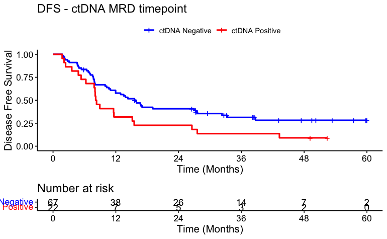

```r
surv_object <-Surv(time = circ_data$DFS_months, event = circ_data$RecStatus)
KM_curve <- survfit(surv_object ~ ctDNA.MRD, data = circ_data,conf.int=0.95,conf.type="log-log")
ggsurvplot(KM_curve, data = circ_data, pval = FALSE, conf.int = FALSE, risk.table = TRUE, break.time.by=12, palette=c("blue","red"), title="DFS - ctDNA MRD timepoint", ylab= "Disease Free Survival", xlab="Time (Months)", legend.labs=c("ctDNA Negative", "ctDNA Positive"), legend.title="")
```

```r
summary(KM_curve, times= c(12, 24))
```

```
Call: survfit(formula = surv_object ~ ctDNA.MRD, data = circ_data,
    conf.int = 0.95, conf.type = "log-log")

                ctDNA.MRD=0
 time n.risk n.event survival std.err lower 95% CI upper 95% CI
   12     38      28    0.577  0.0607        0.450        0.686
   24     26      11    0.407  0.0608        0.288        0.523

                ctDNA.MRD=1
 time n.risk n.event survival std.err lower 95% CI upper 95% CI
   12      7      15    0.318  0.0993       0.1418        0.511
   24      5       2    0.227  0.0893       0.0827        0.414
```

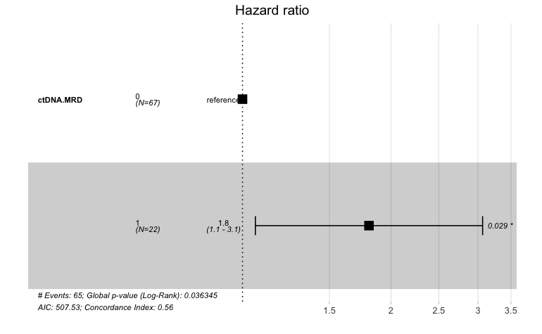

```r
circ_data$ctDNA.MRD <- factor(circ_data$ctDNA.MRD, levels=c("0","1"))
cox_fit <- coxph(surv_object ~ ctDNA.MRD, data=circ_data)
ggforest(cox_fit,data = circ_data)
```

```r
summary(cox_fit)
```

```
Call:
coxph(formula = surv_object ~ ctDNA.MRD, data = circ_data)

  n= 89, number of events= 65

             coef exp(coef) se(coef)     z Pr(>|z|)
ctDNA.MRD1 0.5902    1.8043   0.2705 2.182   0.0291 *
---
Signif. codes:  0 ‘***’ 0.001 ‘**’ 0.01 ‘*’ 0.05 ‘.’ 0.1 ‘ ’ 1

           exp(coef) exp(-coef) lower .95 upper .95
ctDNA.MRD1     1.804     0.5542     1.062     3.066

Concordance= 0.556  (se = 0.028 )
Likelihood ratio test= 4.38  on 1 df,   p=0.04
Wald test            = 4.76  on 1 df,   p=0.03
Score (logrank) test = 4.9  on 1 df,   p=0.03
```

```r
cox_fit_summary <- summary(cox_fit)

# Extract values for HR, 95% CI, and p-value
HR <- cox_fit_summary$coefficients[2]
lower_CI <- cox_fit_summary$conf.int[3]
upper_CI <- cox_fit_summary$conf.int[4]
p_value <- cox_fit_summary$coefficients[5]
label_text <- paste0("HR = ", round(HR, 2), " (", round(lower_CI, 2), "-", round(upper_CI, 2), "); p = ", round(p_value, 3))
print(label_text)
```

```
[1] "HR = 1.8 (1.06-3.07); p = 0.029"
```

#OS by ctDNA at the MRD time point

```r
rm(list=ls())
setwd("~/Downloads")
circ_data <- read.csv("ASAN_ClinicalData_GL_082023.csv")
circ_data$OS_months=circ_data$OS_months-2
circ_data <- circ_data[circ_data$OS_months>=0,]
circ_datadf <- as.data.frame(circ_data)

survfit(Surv(time = circ_data$OS_months, event = circ_data$VitalStatus)~ctDNA.MRD, data = circ_data)
```

```
Call: survfit(formula = Surv(time = circ_data$OS_months, event = circ_data$VitalStatus) ~
    ctDNA.MRD, data = circ_data)

             n events median 0.95LCL 0.95UCL
ctDNA.MRD=0 67     39   38.5    28.9      NA
ctDNA.MRD=1 22     17   30.8    22.6      NA
```

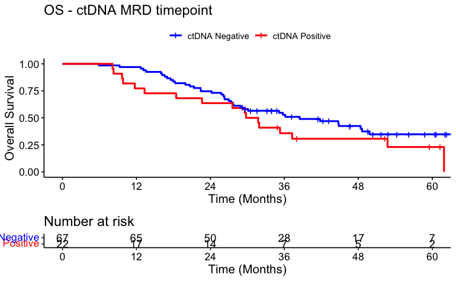

```r
surv_object <-Surv(time = circ_data$OS_months, event = circ_data$VitalStatus)
KM_curve <- survfit(surv_object ~ ctDNA.MRD, data = circ_data,conf.int=0.95,conf.type="log-log")
ggsurvplot(KM_curve, data = circ_data, pval = FALSE, conf.int = FALSE, risk.table = TRUE, break.time.by=12, palette=c("blue","red"), title="OS - ctDNA MRD timepoint", ylab= "Overall Survival", xlab="Time (Months)", legend.labs=c("ctDNA Negative", "ctDNA Positive"), legend.title="")
```

```r
summary(KM_curve, times= c(12, 24))
```

```
Call: survfit(formula = surv_object ~ ctDNA.MRD, data = circ_data,
    conf.int = 0.95, conf.type = "log-log")

                ctDNA.MRD=0
 time n.risk n.event survival std.err lower 95% CI upper 95% CI
   12     65       2    0.970  0.0208        0.886        0.992
   24     50      15    0.746  0.0532        0.624        0.834

                ctDNA.MRD=1
 time n.risk n.event survival std.err lower 95% CI upper 95% CI
   12     17       5    0.773  0.0893        0.537        0.898
   24     14       3    0.636  0.1026        0.403        0.799
```

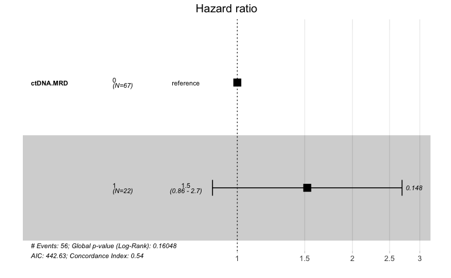

```r
circ_data$ctDNA.MRD <- factor(circ_data$ctDNA.MRD, levels=c("0","1"))
cox_fit <- coxph(surv_object ~ ctDNA.MRD, data=circ_data)
ggforest(cox_fit,data = circ_data)
```

```r
summary(cox_fit)
```

```
Call:
coxph(formula = surv_object ~ ctDNA.MRD, data = circ_data)

  n= 89, number of events= 56

             coef exp(coef) se(coef)     z Pr(>|z|)
ctDNA.MRD1 0.4209    1.5234   0.2911 1.446    0.148

           exp(coef) exp(-coef) lower .95 upper .95
ctDNA.MRD1     1.523     0.6564     0.861     2.695

Concordance= 0.54  (se = 0.032 )
Likelihood ratio test= 1.97  on 1 df,   p=0.2
Wald test            = 2.09  on 1 df,   p=0.1
Score (logrank) test = 2.12  on 1 df,   p=0.1
```

```r
cox_fit_summary <- summary(cox_fit)

# Extract values for HR, 95% CI, and p-value
HR <- cox_fit_summary$coefficients[2]
lower_CI <- cox_fit_summary$conf.int[3]
upper_CI <- cox_fit_summary$conf.int[4]
p_value <- cox_fit_summary$coefficients[5]
label_text <- paste0("HR = ", round(HR, 2), " (", round(lower_CI, 2), "-", round(upper_CI, 2), "); p = ", round(p_value, 3))
print(label_text)
```

```
[1] "HR = 1.52 (0.86-2.7); p = 0.148"
```

#Prognostic role of ctDNA at C5D1

```r
rm(list=ls())
setwd("~/Downloads")
circ_data <- read.csv("ASAN_ClinicalData_GL_082023.csv")
circ_data$DFS_months=circ_data$DFS_months-2
circ_data <- circ_data[circ_data$DFS_months>=0,]
circ_data$DFS_months[circ_data$DFS_months > 60] <- 60
circ_datadf <- as.data.frame(circ_data)

survfit(Surv(time = circ_data$DFS_months, event = circ_data$RecStatus)~ctDNA.C5D1, data = circ_data)
```

```
Call: survfit(formula = Surv(time = circ_data$DFS_months, event = circ_data$RecStatus) ~
    ctDNA.C5D1, data = circ_data)

   1 observation deleted due to missingness
              n events median 0.95LCL 0.95UCL
ctDNA.C5D1=0 71     48   15.9   12.92   27.57
ctDNA.C5D1=1 17     17    4.8    3.09    7.86
```

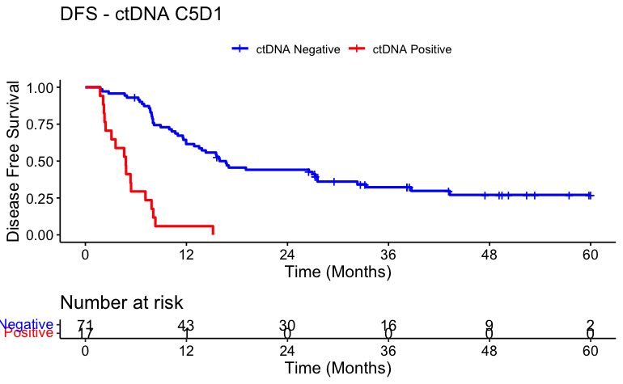

```r
surv_object <-Surv(time = circ_data$DFS_months, event = circ_data$RecStatus)
KM_curve <- survfit(surv_object ~ ctDNA.C5D1, data = circ_data,conf.int=0.95,conf.type="log-log")
ggsurvplot(KM_curve, data = circ_data, pval = FALSE, conf.int = FALSE, risk.table = TRUE, break.time.by=12, palette=c("blue","red"), title="DFS - ctDNA C5D1", ylab= "Disease Free Survival", xlab="Time (Months)", legend.labs=c("ctDNA Negative", "ctDNA Positive"), legend.title="")
```

```r
summary(KM_curve, times= c(12, 24))
```

```
Call: survfit(formula = surv_object ~ ctDNA.C5D1, data = circ_data,
    conf.int = 0.95, conf.type = "log-log")

1 observation deleted due to missingness
                ctDNA.C5D1=0
 time n.risk n.event survival std.err lower 95% CI upper 95% CI
   12     43      27    0.615  0.0581        0.491        0.717
   24     30      12    0.441  0.0596        0.323        0.553

                ctDNA.C5D1=1
        time       n.risk      n.event     survival      std.err lower 95% CI upper 95% CI
    12.00000      1.00000     16.00000      0.05882      0.05707      0.00391      0.23501
```

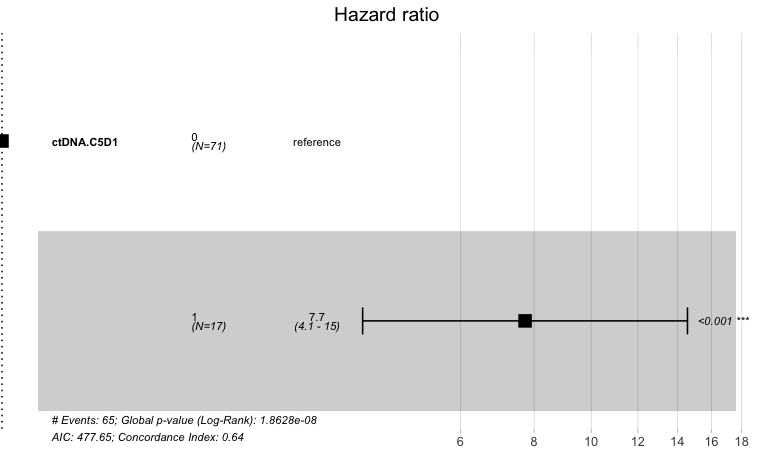

```r
circ_data$ctDNA.C5D1 <- factor(circ_data$ctDNA.C5D1, levels=c("0","1"))
cox_fit <- coxph(surv_object ~ ctDNA.C5D1, data=circ_data)
ggforest(cox_fit,data = circ_data)
```

```r
summary(cox_fit)
```

```
Call:
coxph(formula = surv_object ~ ctDNA.C5D1, data = circ_data)

  n= 88, number of events= 65
   (1 observation deleted due to missingness)

              coef exp(coef) se(coef)     z Pr(>|z|)
ctDNA.C5D11 2.0439    7.7207   0.3238 6.312 2.76e-10 ***
---
Signif. codes:  0 ‘***’ 0.001 ‘**’ 0.01 ‘*’ 0.05 ‘.’ 0.1 ‘ ’ 1

            exp(coef) exp(-coef) lower .95 upper .95
ctDNA.C5D11     7.721     0.1295     4.093     14.56

Concordance= 0.638  (se = 0.026 )
Likelihood ratio test= 31.63  on 1 df,   p=2e-08
Wald test            = 39.84  on 1 df,   p=3e-10
Score (logrank) test = 53.01  on 1 df,   p=3e-13
```

```r
cox_fit_summary <- summary(cox_fit)

# Extract values for HR, 95% CI, and p-value
HR <- cox_fit_summary$coefficients[2]
lower_CI <- cox_fit_summary$conf.int[3]
upper_CI <- cox_fit_summary$conf.int[4]
p_value <- cox_fit_summary$coefficients[5]
label_text <- paste0("HR = ", round(HR, 2), " (", round(lower_CI, 2), "-", round(upper_CI, 2), "); p = ", round(p_value, 3))
print(label_text)
```

```
[1] "HR = 7.72 (4.09-14.56); p = 0"
```

#Multivariate regression model for DFS at the C5D1

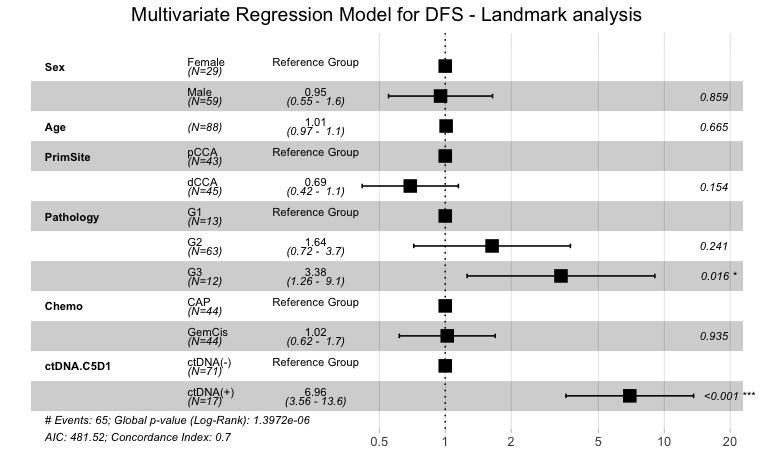

```r
rm(list=ls())
setwd("~/Downloads")
circ_data <- read.csv("ASAN_ClinicalData_GL_082023.csv")
circ_data <- subset(circ_data, !is.na(ctDNA.C5D1))
circ_data$DFS_months=circ_data$DFS_months-2
circ_data <- circ_data[circ_data$DFS_months>=0,]
circ_data$DFS_months[circ_data$DFS_months > 60] <- 60
circ_datadf <- as.data.frame(circ_data)
circ_datadf$Sex <- factor(circ_datadf$Sex, levels = c("2", "1"), labels = c("Female", "Male"))
circ_datadf$PrimSite <- factor(circ_datadf$PrimSite, levels = c("1", "2"), labels = c("pCCA", "dCCA"))
circ_datadf$Pathology <- factor(circ_datadf$Pathology, levels = c("1", "2", "3"), labels = c("G1", "G2", "G3"))
circ_datadf$Chemo <- factor(circ_datadf$Chemo, levels = c("1", "2"), labels = c("CAP", "GemCis"))
circ_datadf$Stage <- factor(circ_datadf$Stage, levels = c("2", "3", "4"), labels = c("2", "3", "4"))
circ_datadf$TP53 <- factor(circ_datadf$TP53, levels = c("WT", "Mut"))
circ_datadf$ctDNA.C5D1 <- factor(circ_datadf$ctDNA.C5D1, levels = c("0", "1"), labels = c("ctDNA(-)", "ctDNA(+)"))
surv_object<-Surv(time = circ_datadf$DFS_months, event = circ_datadf$RecStatus)
cox_fit <- coxph(surv_object ~ Sex + Age + PrimSite + Pathology + Chemo + ctDNA.C5D1, data=circ_datadf)
ggforest(cox_fit, data = circ_datadf, main = "Multivariate Regression Model for DFS - Landmark analysis", refLabel = "Reference Group")
```

```r
test.ph <- cox.zph(cox_fit)
```

#Univariate regression model for factors used at the C5D1 MVA

```r
rm(list=ls())
setwd("~/Downloads")
circ_data <- read.csv("ASAN_ClinicalData_GL_082023.csv")
circ_data <- subset(circ_data, !is.na(ctDNA.C5D1))
circ_data$DFS_months=circ_data$DFS_months-2
circ_data <- circ_data[circ_data$DFS_months>=0,]
circ_datadf <- as.data.frame(circ_data)
surv_object <-Surv(time = circ_data$DFS_months, event = circ_data$RecStatus)
circ_data$Sex <- factor(circ_data$Sex, levels = c("2", "1"), labels = c("Female", "Male")) #univariate for gender
cox_fit <- coxph(surv_object ~ Sex, data=circ_data)
summary(cox_fit)
```

```
Call:
coxph(formula = surv_object ~ Sex, data = circ_data)

  n= 88, number of events= 65

           coef exp(coef) se(coef)     z Pr(>|z|)
SexMale 0.09924   1.10433  0.26891 0.369    0.712

        exp(coef) exp(-coef) lower .95 upper .95
SexMale     1.104     0.9055    0.6519     1.871

Concordance= 0.51  (se = 0.031 )
Likelihood ratio test= 0.14  on 1 df,   p=0.7
Wald test            = 0.14  on 1 df,   p=0.7
Score (logrank) test = 0.14  on 1 df,   p=0.7
```

```r
cox_fit_summary <- summary(cox_fit)
HR <- cox_fit_summary$coefficients[2]
lower_CI <- cox_fit_summary$conf.int[3]
upper_CI <- cox_fit_summary$conf.int[4]
p_value <- cox_fit_summary$coefficients[5]
label_text <- paste0("HR = ", round(HR, 2), " (", round(lower_CI, 2), "-", round(upper_CI, 2), "); p = ", round(p_value, 3))
print(label_text)
```

```
[1] "HR = 1.1 (0.65-1.87); p = 0.712"
```

```r
rm(list=ls())
setwd("~/Downloads")
circ_data <- read.csv("ASAN_ClinicalData_GL_082023.csv")
circ_data <- subset(circ_data, !is.na(ctDNA.C5D1))
circ_data$DFS_months=circ_data$DFS_months-2
circ_data <- circ_data[circ_data$DFS_months>=0,]
circ_datadf <- as.data.frame(circ_data)
surv_object <-Surv(time = circ_data$DFS_months, event = circ_data$RecStatus)
cox_fit <- coxph(surv_object ~ Age, data=circ_data) #univariate for age
summary(cox_fit)
```

```
Call:
coxph(formula = surv_object ~ Age, data = circ_data)

  n= 88, number of events= 65

        coef exp(coef) se(coef)     z Pr(>|z|)
Age 0.008003  1.008035 0.019813 0.404    0.686

    exp(coef) exp(-coef) lower .95 upper .95
Age     1.008      0.992    0.9696     1.048

Concordance= 0.501  (se = 0.041 )
Likelihood ratio test= 0.16  on 1 df,   p=0.7
Wald test            = 0.16  on 1 df,   p=0.7
Score (logrank) test = 0.16  on 1 df,   p=0.7
```

```r
cox_fit_summary <- summary(cox_fit)
HR <- cox_fit_summary$coefficients[2]
lower_CI <- cox_fit_summary$conf.int[3]
upper_CI <- cox_fit_summary$conf.int[4]
p_value <- cox_fit_summary$coefficients[5]
label_text <- paste0("HR = ", round(HR, 2), " (", round(lower_CI, 2), "-", round(upper_CI, 2), "); p = ", round(p_value, 3))
print(label_text)
```

```
[1] "HR = 1.01 (0.97-1.05); p = 0.686"
```

```r
rm(list=ls())
setwd("~/Downloads")
circ_data <- read.csv("ASAN_ClinicalData_GL_082023.csv")
circ_data <- subset(circ_data, !is.na(ctDNA.C5D1))
circ_data$DFS_months=circ_data$DFS_months-2
circ_data <- circ_data[circ_data$DFS_months>=0,]
circ_datadf <- as.data.frame(circ_data)
surv_object <-Surv(time = circ_data$DFS_months, event = circ_data$RecStatus)
circ_data$PrimSite <- factor(circ_data$PrimSite, levels = c("1", "2"), labels = c("pCCA", "dCCA")) #univariate for Primary Site
cox_fit <- coxph(surv_object ~ PrimSite, data=circ_data)
summary(cox_fit)
```

```
Call:
coxph(formula = surv_object ~ PrimSite, data = circ_data)

  n= 88, number of events= 65

                coef exp(coef) se(coef)     z Pr(>|z|)
PrimSitedCCA -0.4183    0.6581   0.2520 -1.66   0.0969 .
---
Signif. codes:  0 ‘***’ 0.001 ‘**’ 0.01 ‘*’ 0.05 ‘.’ 0.1 ‘ ’ 1

             exp(coef) exp(-coef) lower .95 upper .95
PrimSitedCCA    0.6581      1.519    0.4016     1.078

Concordance= 0.531  (se = 0.034 )
Likelihood ratio test= 2.79  on 1 df,   p=0.09
Wald test            = 2.76  on 1 df,   p=0.1
Score (logrank) test = 2.8  on 1 df,   p=0.09
```

```r
cox_fit_summary <- summary(cox_fit)
HR <- cox_fit_summary$coefficients[2]
lower_CI <- cox_fit_summary$conf.int[3]
upper_CI <- cox_fit_summary$conf.int[4]
p_value <- cox_fit_summary$coefficients[5]
label_text <- paste0("HR = ", round(HR, 2), " (", round(lower_CI, 2), "-", round(upper_CI, 2), "); p = ", round(p_value, 3))
print(label_text)
```

```
[1] "HR = 0.66 (0.4-1.08); p = 0.097"
```

```r
rm(list=ls())
setwd("~/Downloads")
circ_data <- read.csv("ASAN_ClinicalData_GL_082023.csv")
circ_data <- subset(circ_data, !is.na(ctDNA.C5D1))
circ_data$DFS_months=circ_data$DFS_months-2
circ_data <- circ_data[circ_data$DFS_months>=0,]
circ_datadf <- as.data.frame(circ_data)
surv_object <-Surv(time = circ_data$DFS_months, event = circ_data$RecStatus)
KM_curve <- survfit(surv_object ~ Pathology, data = circ_data,conf.int=0.95,conf.type="log-log")
ggsurvplot(KM_curve, data = circ_data, pval = TRUE, conf.int = FALSE, risk.table = TRUE, break.time.by=3, palette=c("blue","green","red"), title="DFS - ctDNA C5D1 - Grade", ylab= "Disease Free Survival", xlab="Time (Months)", legend.labs=c("G1", "G2", "G3"), legend.title="")
circ_data$Pathology <- factor(circ_data$Pathology, levels = c("1", "2", "3"), labels = c("G1", "G2", "G3")) #univariate for Grade
cox_fit <- coxph(surv_object ~ Pathology, data=circ_data)
ggforest(cox_fit,data = circ_data)
```

[output not shown]

```r
summary(cox_fit)
```

```
Call:
coxph(formula = surv_object ~ Pathology, data = circ_data)

  n= 88, number of events= 65

              coef exp(coef) se(coef)     z Pr(>|z|)
PathologyG2 0.6850    1.9838   0.4068 1.684   0.0922 .
PathologyG3 1.3673    3.9247   0.4871 2.807   0.0050 **
---
Signif. codes:  0 ‘***’ 0.001 ‘**’ 0.01 ‘*’ 0.05 ‘.’ 0.1 ‘ ’ 1

            exp(coef) exp(-coef) lower .95 upper .95
PathologyG2     1.984     0.5041    0.8939     4.403
PathologyG3     3.925     0.2548    1.5108    10.196

Concordance= 0.6  (se = 0.031 )
Likelihood ratio test= 8.16  on 2 df,   p=0.02
Wald test            = 8.15  on 2 df,   p=0.02
Score (logrank) test = 8.73  on 2 df,   p=0.01
```

```r
rm(list=ls())
setwd("~/Downloads")
circ_data <- read.csv("ASAN_ClinicalData_GL_082023.csv")
circ_data <- subset(circ_data, !is.na(ctDNA.C5D1))
circ_data$DFS_months=circ_data$DFS_months-2
circ_data <- circ_data[circ_data$DFS_months>=0,]
circ_datadf <- as.data.frame(circ_data)
surv_object <-Surv(time = circ_data$DFS_months, event = circ_data$RecStatus)
circ_data$Chemo <- factor(circ_data$Chemo, levels = c("1", "2"), labels = c("CAP", "GemCis")) #univariate for Chemotherapy
cox_fit <- coxph(surv_object ~ Chemo, data=circ_data)
summary(cox_fit)
```

```
Call:
coxph(formula = surv_object ~ Chemo, data = circ_data)

  n= 88, number of events= 65

               coef exp(coef) se(coef)     z Pr(>|z|)
ChemoGemCis 0.01524   1.01536  0.24845 0.061    0.951

            exp(coef) exp(-coef) lower .95 upper .95
ChemoGemCis     1.015     0.9849    0.6239     1.652

Concordance= 0.498  (se = 0.034 )
Likelihood ratio test= 0  on 1 df,   p=1
Wald test            = 0  on 1 df,   p=1
Score (logrank) test = 0  on 1 df,   p=1
```

```r
cox_fit_summary <- summary(cox_fit)
HR <- cox_fit_summary$coefficients[2]
lower_CI <- cox_fit_summary$conf.int[3]
upper_CI <- cox_fit_summary$conf.int[4]
p_value <- cox_fit_summary$coefficients[5]
label_text <- paste0("HR = ", round(HR, 2), " (", round(lower_CI, 2), "-", round(upper_CI, 2), "); p = ", round(p_value, 3))
print(label_text)
```

```
[1] "HR = 1.02 (0.62-1.65); p = 0.951"
```

```r
rm(list=ls())
setwd("~/Downloads")
circ_data <- read.csv("ASAN_ClinicalData_GL_082023.csv")
circ_data <- subset(circ_data, !is.na(ctDNA.C5D1))
circ_data$DFS_months=circ_data$DFS_months-2
circ_data <- circ_data[circ_data$DFS_months>=0,]
circ_datadf <- as.data.frame(circ_data)
surv_object <-Surv(time = circ_data$DFS_months, event = circ_data$RecStatus)
KM_curve <- survfit(surv_object ~ Stage, data = circ_data,conf.int=0.95,conf.type="log-log")
ggsurvplot(KM_curve, data = circ_data, pval = TRUE, conf.int = FALSE, risk.table = TRUE, break.time.by=3, palette=c("blue","green","red"), title="DFS - ctDNA C5D1 - Stage", ylab= "Disease Free Survival", xlab="Time (Months)", legend.labs=c("II", "III", "IV"), legend.title="")
circ_data$Stage <- factor(circ_data$Stage, levels = c("2", "3", "4"), labels = c("2", "3", "4")) #univariate for Stage
cox_fit <- coxph(surv_object ~ Stage, data=circ_data)
ggforest(cox_fit,data = circ_data)
```

[output not shown]

```r
summary(cox_fit)
```

```
Call:
coxph(formula = surv_object ~ Stage, data = circ_data)

  n= 88, number of events= 65

         coef exp(coef) se(coef)     z Pr(>|z|)
Stage3 0.2219    1.2484   0.2794 0.794  0.42717
Stage4 1.1045    3.0178   0.3660 3.018  0.00254 **
---
Signif. codes:  0 ‘***’ 0.001 ‘**’ 0.01 ‘*’ 0.05 ‘.’ 0.1 ‘ ’ 1

       exp(coef) exp(-coef) lower .95 upper .95
Stage3     1.248     0.8010     0.722     2.159
Stage4     3.018     0.3314     1.473     6.183

Concordance= 0.562  (se = 0.037 )
Likelihood ratio test= 8.03  on 2 df,   p=0.02
Wald test            = 9.53  on 2 df,   p=0.009
Score (logrank) test = 10.31  on 2 df,   p=0.006
```

```r
rm(list=ls())
setwd("~/Downloads")
circ_data <- read.csv("ASAN_ClinicalData_GL_082023.csv")
circ_data <- subset(circ_data, !is.na(ctDNA.C5D1))
circ_data$DFS_months=circ_data$DFS_months-2
circ_data <- circ_data[circ_data$DFS_months>=0,]
circ_datadf <- as.data.frame(circ_data)
surv_object <-Surv(time = circ_data$DFS_months, event = circ_data$RecStatus)
circ_data$ctDNA.C5D1 <- factor(circ_data$ctDNA.C5D1, levels = c("0", "1"), labels = c("ctDNA(-)", "ctDNA(+)")) #univariate for ctDNA C5D1
cox_fit <- coxph(surv_object ~ ctDNA.C5D1, data=circ_data)
summary(cox_fit)
```

```
Call:
coxph(formula = surv_object ~ ctDNA.C5D1, data = circ_data)

  n= 88, number of events= 65

                     coef exp(coef) se(coef)     z Pr(>|z|)
ctDNA.C5D1ctDNA(+) 2.0439    7.7207   0.3238 6.312 2.76e-10 ***
---
Signif. codes:  0 ‘***’ 0.001 ‘**’ 0.01 ‘*’ 0.05 ‘.’ 0.1 ‘ ’ 1

                   exp(coef) exp(-coef) lower .95 upper .95
ctDNA.C5D1ctDNA(+)     7.721     0.1295     4.093     14.56

Concordance= 0.638  (se = 0.026 )
Likelihood ratio test= 31.63  on 1 df,   p=2e-08
Wald test            = 39.84  on 1 df,   p=3e-10
Score (logrank) test = 53.01  on 1 df,   p=3e-13
```

```r
cox_fit_summary <- summary(cox_fit)
HR <- cox_fit_summary$coefficients[2]
lower_CI <- cox_fit_summary$conf.int[3]
upper_CI <- cox_fit_summary$conf.int[4]
p_value <- cox_fit_summary$coefficients[5]
label_text <- paste0("HR = ", round(HR, 2), " (", round(lower_CI, 2), "-", round(upper_CI, 2), "); p = ", round(p_value, 3))
print(label_text)
```

```
[1] "HR = 7.72 (4.09-14.56); p = 0"
```

#Clinical Nomogram for C5D1

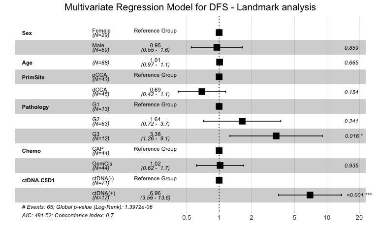

```r
rm(list=ls())
setwd("~/Downloads")
circ_data <- read.csv("ASAN_ClinicalData_GL_082023.csv")
circ_data <- subset(circ_data, !is.na(ctDNA.C5D1))
circ_data$DFS_months=circ_data$DFS_months-2
circ_data <- circ_data[circ_data$DFS_months>=0,]
circ_data$DFS_months[circ_data$DFS_months > 60] <- 60
circ_datadf <- as.data.frame(circ_data)

circ_datadf$Sex <- factor(circ_datadf$Sex, levels = c("2", "1"), labels = c("Female", "Male"))
circ_datadf$PrimSite <- factor(circ_datadf$PrimSite, levels = c("1", "2"), labels = c("pCCA", "dCCA"))
circ_datadf$Pathology <- factor(circ_datadf$Pathology, levels = c("1", "2", "3"), labels = c("G1", "G2", "G3"))
circ_datadf$Chemo <- factor(circ_datadf$Chemo, levels = c("1", "2"), labels = c("CAP", "GemCis"))
circ_datadf$Stage <- factor(circ_datadf$Stage, levels = c("2", "3", "4"), labels = c("2", "3", "4"))
circ_datadf$ctDNA.C5D1 <- factor(circ_datadf$ctDNA.C5D1, levels = c("0", "1"), labels = c("ctDNA(-)", "ctDNA(+)"))
surv_object<-Surv(time = circ_datadf$DFS_months, event = circ_datadf$RecStatus)
cox_fit <- coxph(surv_object ~ Sex + Age + PrimSite + Pathology + Chemo + ctDNA.C5D1, data=circ_datadf)
ggforest(cox_fit, data = circ_datadf, main = "Multivariate Regression Model for DFS - Landmark analysis", refLabel = "Reference Group")
```

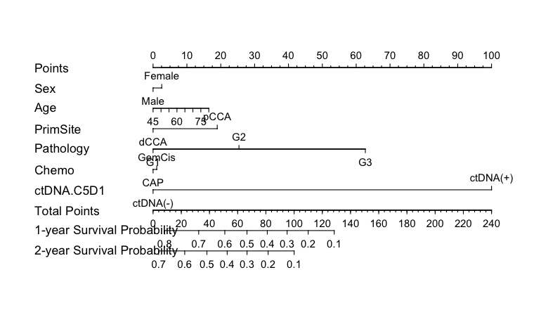

```r
test.ph <- cox.zph(cox_fit)

ddist <- datadist(circ_datadf)
options(datadist='ddist')
mod.Cox <- cph(Surv(DFS_months, RecStatus) ~Sex + Age + PrimSite + Pathology + Chemo + ctDNA.C5D1, circ_datadf,surv=TRUE)
surv.Cox <- Survival(mod.Cox)
nom.Cox <- nomogram(mod.Cox,
                    fun=list(function(x) surv.Cox(12, x), function(x) surv.Cox(24, x)),
                    funlabel=c("1-year Survival Probability", "2-year Survival Probability"),
                    lp=FALSE)
plot(nom.Cox)
```

#OS by ctDNA at C5D1

```r
rm(list=ls())
setwd("~/Downloads")
circ_data <- read.csv("ASAN_ClinicalData_GL_082023.csv")
circ_data$OS_months=circ_data$OS_months-2
circ_data <- circ_data[circ_data$OS_months>=0,]
circ_datadf <- as.data.frame(circ_data)

survfit(Surv(time = circ_data$OS_months, event = circ_data$VitalStatus)~ctDNA.C5D1, data = circ_data)
```

```
Call: survfit(formula = Surv(time = circ_data$OS_months, event = circ_data$VitalStatus) ~
    ctDNA.C5D1, data = circ_data)

   1 observation deleted due to missingness
              n events median 0.95LCL 0.95UCL
ctDNA.C5D1=0 71     39   44.8    31.7      NA
ctDNA.C5D1=1 17     17   18.4    13.1    35.3
```

```r
surv_object <-Surv(time = circ_data$OS_months, event = circ_data$VitalStatus)
KM_curve <- survfit(surv_object ~ ctDNA.C5D1, data = circ_data,conf.int=0.95,conf.type="log-log")
ggsurvplot(KM_curve, data = circ_data, pval = FALSE, conf.int = FALSE, risk.table = TRUE, break.time.by=12, palette=c("blue","red"), title="OS - ctDNA at C5D1", ylab= "Overall Survival", xlab="Time (Months)", legend.labs=c("ctDNA Negative", "ctDNA Positive"), legend.title="")
summary(KM_curve, times= c(12, 24))
```

[output not shown]

```
Call: survfit(formula = surv_object ~ ctDNA.C5D1, data = circ_data,
    conf.int = 0.95, conf.type = "log-log")

1 observation deleted due to missingness
                ctDNA.C5D1=0
 time n.risk n.event survival std.err lower 95% CI upper 95% CI
   12     69       2    0.972  0.0196        0.892        0.993
   24     56      13    0.789  0.0484        0.674        0.867

                ctDNA.C5D1=1
 time n.risk n.event survival std.err lower 95% CI upper 95% CI
   12     12       5    0.706   0.111        0.431        0.866
   24      7       5    0.412   0.119        0.186        0.626
```

```r
circ_data$ctDNA.C5D1 <- factor(circ_data$ctDNA.C5D1, levels=c("0","1"))
cox_fit <- coxph(surv_object ~ ctDNA.C5D1, data=circ_data)
ggforest(cox_fit,data = circ_data)
```

[output not shown]

```r
summary(cox_fit)
```

```
Call:
coxph(formula = surv_object ~ ctDNA.C5D1, data = circ_data)

  n= 88, number of events= 56
   (1 observation deleted due to missingness)

              coef exp(coef) se(coef)     z Pr(>|z|)
ctDNA.C5D11 1.2634    3.5375   0.2983 4.235 2.29e-05 ***
---
Signif. codes:  0 ‘***’ 0.001 ‘**’ 0.01 ‘*’ 0.05 ‘.’ 0.1 ‘ ’ 1

            exp(coef) exp(-coef) lower .95 upper .95
ctDNA.C5D11     3.537     0.2827     1.971     6.348

Concordance= 0.603  (se = 0.029 )
Likelihood ratio test= 14.98  on 1 df,   p=1e-04
Wald test            = 17.93  on 1 df,   p=2e-05
Score (logrank) test = 20.38  on 1 df,   p=6e-06
```

```r
cox_fit_summary <- summary(cox_fit)

# Extract values for HR, 95% CI, and p-value
HR <- cox_fit_summary$coefficients[2]
lower_CI <- cox_fit_summary$conf.int[3]
upper_CI <- cox_fit_summary$conf.int[4]
p_value <- cox_fit_summary$coefficients[5]
label_text <- paste0("HR = ", round(HR, 2), " (", round(lower_CI, 2), "-", round(upper_CI, 2), "); p = ", round(p_value, 3))
print(label_text)
```

```
[1] "HR = 3.54 (1.97-6.35); p = 0"
```

#Prognostic role of ctDNA at C8D1

```r
rm(list=ls())
setwd("~/Downloads")
circ_data <- read.csv("ASAN_ClinicalData_GL_082023.csv")
circ_data$DFS_months=circ_data$DFS_months-2
circ_data <- circ_data[circ_data$DFS_months>=0,]
circ_data$DFS_months[circ_data$DFS_months > 60] <- 60
circ_datadf <- as.data.frame(circ_data)

survfit(Surv(time = circ_data$DFS_months, event = circ_data$RecStatus)~ctDNA.C8D1, data = circ_data)
```

```
Call: survfit(formula = Surv(time = circ_data$DFS_months, event = circ_data$RecStatus) ~
    ctDNA.C8D1, data = circ_data)

   12 observations deleted due to missingness
              n events median 0.95LCL 0.95UCL
ctDNA.C8D1=0 62     40  17.02   13.84    33.4
ctDNA.C8D1=1 15     15   7.13    5.36    15.2
```

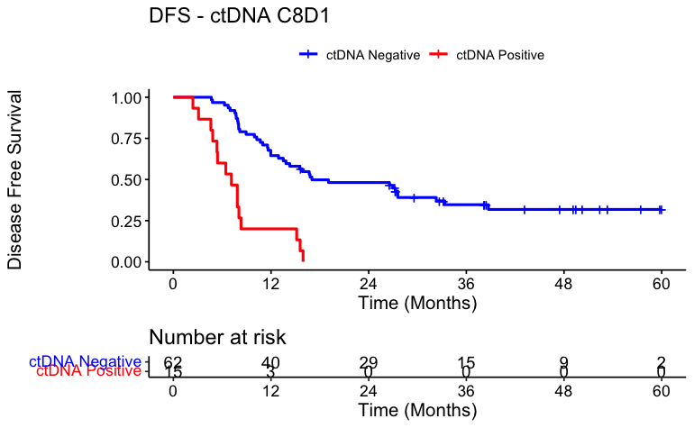

```r
surv_object <-Surv(time = circ_data$DFS_months, event = circ_data$RecStatus)
KM_curve <- survfit(surv_object ~ ctDNA.C8D1, data = circ_data,conf.int=0.95,conf.type="log-log")
ggsurvplot(KM_curve, data = circ_data, pval = FALSE, conf.int = FALSE, risk.table = TRUE, break.time.by=12, palette=c("blue","red"), title="DFS - ctDNA C8D1", ylab= "Disease Free Survival", xlab="Time (Months)", legend.labs=c("ctDNA Negative", "ctDNA Positive"), legend.title="")
```

```r
summary(KM_curve, times= c(12, 24))
```

```
Call: survfit(formula = surv_object ~ ctDNA.C8D1, data = circ_data,
    conf.int = 0.95, conf.type = "log-log")

12 observations deleted due to missingness
                ctDNA.C8D1=0
 time n.risk n.event survival std.err lower 95% CI upper 95% CI
   12     40      22    0.645  0.0608        0.513        0.750
   24     29      10    0.481  0.0637        0.353        0.599

                ctDNA.C8D1=1
        time       n.risk      n.event     survival      std.err lower 95% CI upper 95% CI
     12.0000       3.0000      12.0000       0.2000       0.1033       0.0489       0.4239
```

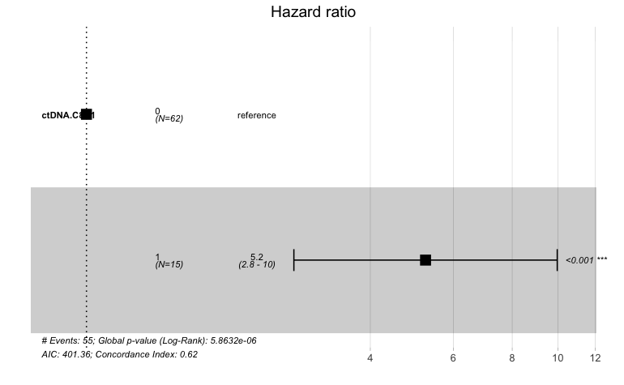

```r
circ_data$ctDNA.C8D1 <- factor(circ_data$ctDNA.C8D1, levels=c("0","1"))
cox_fit <- coxph(surv_object ~ ctDNA.C8D1, data=circ_data)
ggforest(cox_fit,data = circ_data)
```

```r
summary(cox_fit)
```

```
Call:
coxph(formula = surv_object ~ ctDNA.C8D1, data = circ_data)

  n= 77, number of events= 55
   (12 observations deleted due to missingness)

              coef exp(coef) se(coef)     z Pr(>|z|)
ctDNA.C8D11 1.6561    5.2389   0.3281 5.047 4.49e-07 ***
---
Signif. codes:  0 ‘***’ 0.001 ‘**’ 0.01 ‘*’ 0.05 ‘.’ 0.1 ‘ ’ 1

            exp(coef) exp(-coef) lower .95 upper .95
ctDNA.C8D11     5.239     0.1909     2.754     9.967

Concordance= 0.624  (se = 0.028 )
Likelihood ratio test= 20.53  on 1 df,   p=6e-06
Wald test            = 25.47  on 1 df,   p=4e-07
Score (logrank) test = 31.38  on 1 df,   p=2e-08
```

```r
cox_fit_summary <- summary(cox_fit)

# Extract values for HR, 95% CI, and p-value
HR <- cox_fit_summary$coefficients[2]
lower_CI <- cox_fit_summary$conf.int[3]
upper_CI <- cox_fit_summary$conf.int[4]
p_value <- cox_fit_summary$coefficients[5]
label_text <- paste0("HR = ", round(HR, 2), " (", round(lower_CI, 2), "-", round(upper_CI, 2), "); p = ", round(p_value, 3))
print(label_text)
```

```
[1] "HR = 5.24 (2.75-9.97); p = 0"
```

#OS by ctDNA at C8D1

```r
rm(list=ls())
setwd("~/Downloads")
circ_data <- read.csv("ASAN_ClinicalData_GL_082023.csv")
circ_data$OS_months=circ_data$OS_months-2
circ_data <- circ_data[circ_data$OS_months>=0,]
circ_datadf <- as.data.frame(circ_data)

survfit(Surv(time = circ_data$OS_months, event = circ_data$VitalStatus)~ctDNA.C8D1, data = circ_data)
```

```
Call: survfit(formula = Surv(time = circ_data$OS_months, event = circ_data$VitalStatus) ~
    ctDNA.C8D1, data = circ_data)

   12 observations deleted due to missingness
              n events median 0.95LCL 0.95UCL
ctDNA.C8D1=0 62     32   48.4    30.1      NA
ctDNA.C8D1=1 15     15   29.8    17.5    41.8
```

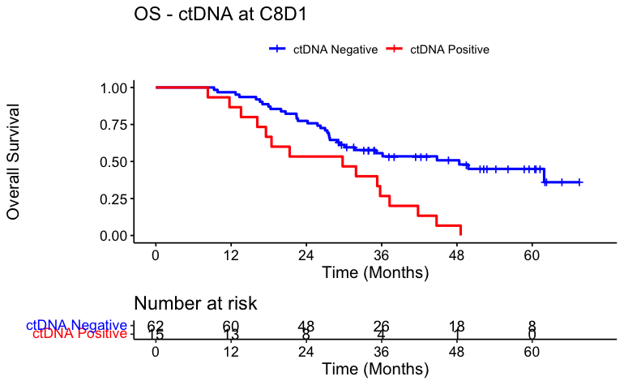

```r
surv_object <-Surv(time = circ_data$OS_months, event = circ_data$VitalStatus)
KM_curve <- survfit(surv_object ~ ctDNA.C8D1, data = circ_data,conf.int=0.95,conf.type="log-log")
ggsurvplot(KM_curve, data = circ_data, pval = FALSE, conf.int = FALSE, risk.table = TRUE, break.time.by=12, palette=c("blue","red"), title="OS - ctDNA at C8D1", ylab= "Overall Survival", xlab="Time (Months)", legend.labs=c("ctDNA Negative", "ctDNA Positive"), legend.title="")
```

```r
summary(KM_curve, times= c(12, 24))
```

```
Call: survfit(formula = surv_object ~ ctDNA.C8D1, data = circ_data,
    conf.int = 0.95, conf.type = "log-log")

12 observations deleted due to missingness
                ctDNA.C8D1=0
 time n.risk n.event survival std.err lower 95% CI upper 95% CI
   12     60       2    0.968  0.0224        0.877        0.992
   24     48      12    0.774  0.0531        0.649        0.860

                ctDNA.C8D1=1
 time n.risk n.event survival std.err lower 95% CI upper 95% CI
   12     13       2    0.867  0.0878        0.564        0.965
   24      8       5    0.533  0.1288        0.263        0.744
```

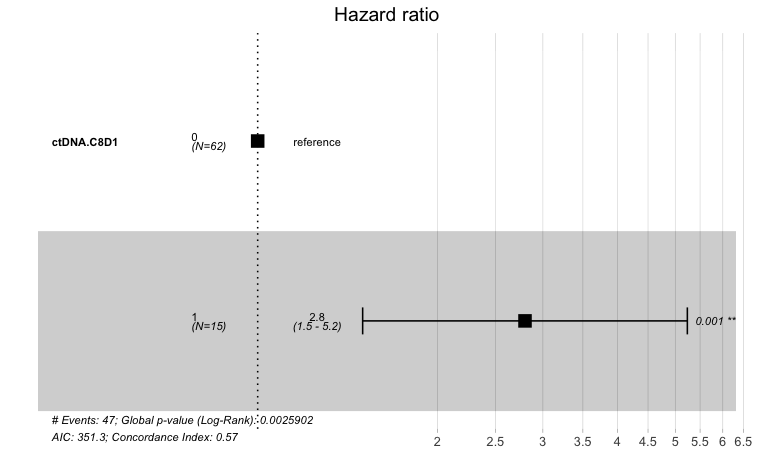

```r
circ_data$ctDNA.C8D1 <- factor(circ_data$ctDNA.C8D1, levels=c("0","1"))
cox_fit <- coxph(surv_object ~ ctDNA.C8D1, data=circ_data)
ggforest(cox_fit,data = circ_data)
```

```r
summary(cox_fit)
```

```
Call:
coxph(formula = surv_object ~ ctDNA.C8D1, data = circ_data)

  n= 77, number of events= 47
   (12 observations deleted due to missingness)

              coef exp(coef) se(coef)     z Pr(>|z|)
ctDNA.C8D11 1.0300    2.8011   0.3192 3.227  0.00125 **
---
Signif. codes:  0 ‘***’ 0.001 ‘**’ 0.01 ‘*’ 0.05 ‘.’ 0.1 ‘ ’ 1

            exp(coef) exp(-coef) lower .95 upper .95
ctDNA.C8D11     2.801      0.357     1.499     5.236

Concordance= 0.574  (se = 0.031 )
Likelihood ratio test= 9.08  on 1 df,   p=0.003
Wald test            = 10.42  on 1 df,   p=0.001
Score (logrank) test = 11.35  on 1 df,   p=8e-04
```

```r
cox_fit_summary <- summary(cox_fit)

# Extract values for HR, 95% CI, and p-value
HR <- cox_fit_summary$coefficients[2]
lower_CI <- cox_fit_summary$conf.int[3]
upper_CI <- cox_fit_summary$conf.int[4]
p_value <- cox_fit_summary$coefficients[5]
label_text <- paste0("HR = ", round(HR, 2), " (", round(lower_CI, 2), "-", round(upper_CI, 2), "); p = ", round(p_value, 3))
print(label_text)
```

```
[1] "HR = 2.8 (1.5-5.24); p = 0.001"
```

#Prognostic role of ctDNA anytime post-surgery

```r
rm(list=ls())
setwd("~/Downloads")
circ_data <- read.csv("ASAN_ClinicalData_GL_082023.csv")
circ_data$DFS_months[circ_data$DFS_months > 60] <- 60
circ_datadf <- as.data.frame(circ_data)

survfit(Surv(time = circ_data$DFS_months, event = circ_data$RecStatus)~MRD_anytime, data = circ_data)
```

```
Call: survfit(formula = Surv(time = circ_data$DFS_months, event = circ_data$RecStatus) ~
    MRD_anytime, data = circ_data)

               n events median 0.95LCL 0.95UCL
MRD_anytime=0 42     20   40.7   21.06      NA
MRD_anytime=1 47     45   10.1    9.56      14
```

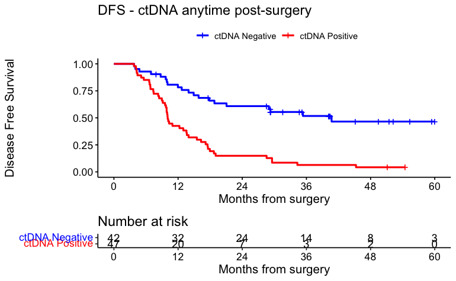

```r
surv_object <-Surv(time = circ_data$DFS_months, event = circ_data$RecStatus)
KM_curve <- survfit(surv_object ~ MRD_anytime, data = circ_data,conf.int=0.95,conf.type="log-log")
ggsurvplot(KM_curve, data = circ_data, pval = FALSE, conf.int = FALSE, risk.table = TRUE, break.time.by=12, palette=c("blue","red"), title="DFS - ctDNA anytime post-surgery", ylab= "Disease Free Survival", xlab="Months from surgery", legend.labs=c("ctDNA Negative", "ctDNA Positive"), legend.title="")
```

```r
summary(KM_curve, times= c(12, 24))
```

```
Call: survfit(formula = surv_object ~ MRD_anytime, data = circ_data,
    conf.int = 0.95, conf.type = "log-log")

                MRD_anytime=0
 time n.risk n.event survival std.err lower 95% CI upper 95% CI
   12     32       9    0.782  0.0642        0.623        0.880
   24     24       7    0.609  0.0766        0.442        0.739

                MRD_anytime=1
 time n.risk n.event survival std.err lower 95% CI upper 95% CI
   12     20      27    0.426  0.0721       0.2835        0.560
   24      7      13    0.149  0.0519       0.0655        0.264
```

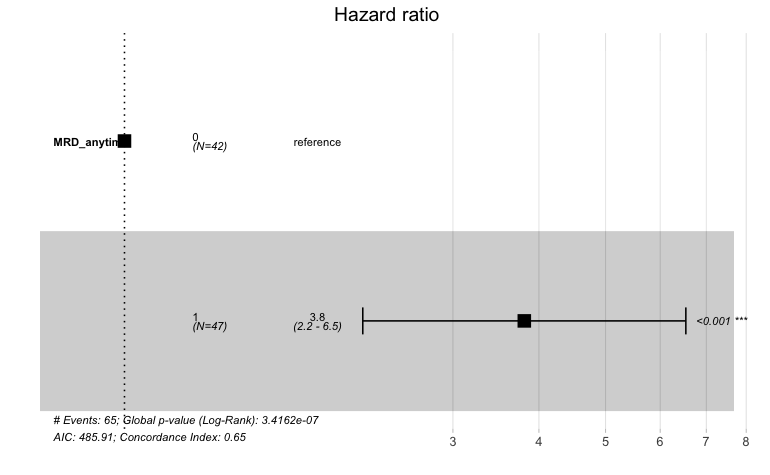

```r
circ_data$MRD_anytime <- factor(circ_data$MRD_anytime, levels=c("0","1"))
cox_fit <- coxph(surv_object ~ MRD_anytime, data=circ_data)
ggforest(cox_fit,data = circ_data)
```

```r
summary(cox_fit)
```

```
Call:
coxph(formula = surv_object ~ MRD_anytime, data = circ_data)

  n= 89, number of events= 65

               coef exp(coef) se(coef)     z Pr(>|z|)
MRD_anytime1 1.3374    3.8090   0.2757 4.851 1.23e-06 ***
---
Signif. codes:  0 ‘***’ 0.001 ‘**’ 0.01 ‘*’ 0.05 ‘.’ 0.1 ‘ ’ 1

             exp(coef) exp(-coef) lower .95 upper .95
MRD_anytime1     3.809     0.2625     2.219     6.538

Concordance= 0.649  (se = 0.03 )
Likelihood ratio test= 26  on 1 df,   p=3e-07
Wald test            = 23.54  on 1 df,   p=1e-06
Score (logrank) test = 26.68  on 1 df,   p=2e-07
```

```r
cox_fit_summary <- summary(cox_fit)

# Extract values for HR, 95% CI, and p-value
HR <- cox_fit_summary$coefficients[2]
lower_CI <- cox_fit_summary$conf.int[3]
upper_CI <- cox_fit_summary$conf.int[4]
p_value <- cox_fit_summary$coefficients[5]
label_text <- paste0("HR = ", round(HR, 2), " (", round(lower_CI, 2), "-", round(upper_CI, 2), "); p = ", round(p_value, 3))
print(label_text)
```

```
[1] "HR = 3.81 (2.22-6.54); p = 0"
```

#OS by ctDNA anytime post-surgery

```r
rm(list=ls())
setwd("~/Downloads")
circ_data <- read.csv("ASAN_ClinicalData_GL_082023.csv")
circ_data$OS_months=circ_data$OS_months-2
circ_data <- circ_data[circ_data$OS_months>=0,]
circ_datadf <- as.data.frame(circ_data)

survfit(Surv(time = circ_data$OS_months, event = circ_data$VitalStatus)~MRD_anytime, data = circ_data)
```

```
Call: survfit(formula = Surv(time = circ_data$OS_months, event = circ_data$VitalStatus) ~
    MRD_anytime, data = circ_data)

               n events median 0.95LCL 0.95UCL
MRD_anytime=0 42     15     NA    48.4      NA
MRD_anytime=1 47     41   27.6    21.3    35.3
```

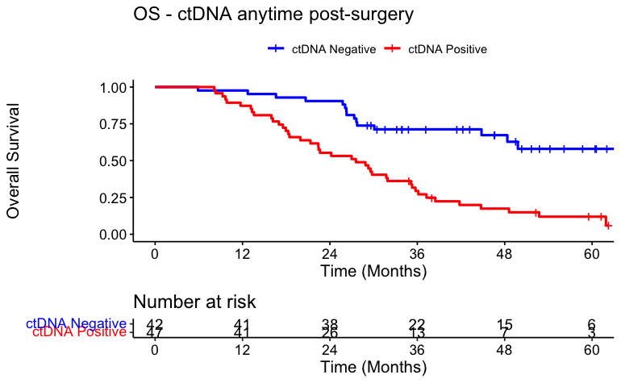

```r
surv_object <-Surv(time = circ_data$OS_months, event = circ_data$VitalStatus)
KM_curve <- survfit(surv_object ~ MRD_anytime, data = circ_data,conf.int=0.95,conf.type="log-log")
ggsurvplot(KM_curve, data = circ_data, pval = FALSE, conf.int = FALSE, risk.table = TRUE, break.time.by=12, palette=c("blue","red"), title="OS - ctDNA anytime post-surgery", ylab= "Overall Survival", xlab="Time (Months)", legend.labs=c("ctDNA Negative", "ctDNA Positive"), legend.title="")
```

```r
summary(KM_curve, times= c(12, 24))
```

```
Call: survfit(formula = surv_object ~ MRD_anytime, data = circ_data,
    conf.int = 0.95, conf.type = "log-log")

                MRD_anytime=0
 time n.risk n.event survival std.err lower 95% CI upper 95% CI
   12     41       1    0.976  0.0235        0.843        0.997
   24     38       3    0.905  0.0453        0.766        0.963

                MRD_anytime=1
 time n.risk n.event survival std.err lower 95% CI upper 95% CI
   12     41       6    0.872  0.0487        0.738        0.941
   24     26      15    0.553  0.0725        0.401        0.681
```

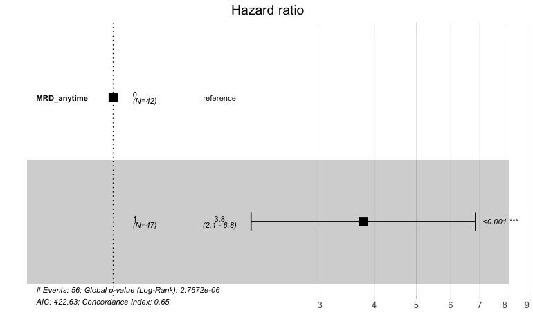

```r
circ_data$MRD_anytime <- factor(circ_data$MRD_anytime, levels=c("0","1"))
cox_fit <- coxph(surv_object ~ MRD_anytime, data=circ_data)
ggforest(cox_fit,data = circ_data)
```

```r
summary(cox_fit)
```

```
Call:
coxph(formula = surv_object ~ MRD_anytime, data = circ_data)

  n= 89, number of events= 56

               coef exp(coef) se(coef)     z Pr(>|z|)
MRD_anytime1 1.3272    3.7706   0.3039 4.367 1.26e-05 ***
---
Signif. codes:  0 ‘***’ 0.001 ‘**’ 0.01 ‘*’ 0.05 ‘.’ 0.1 ‘ ’ 1

             exp(coef) exp(-coef) lower .95 upper .95
MRD_anytime1     3.771     0.2652     2.078     6.841

Concordance= 0.648  (se = 0.033 )
Likelihood ratio test= 21.97  on 1 df,   p=3e-06
Wald test            = 19.07  on 1 df,   p=1e-05
Score (logrank) test = 21.89  on 1 df,   p=3e-06
```

```r
cox_fit_summary <- summary(cox_fit)

# Extract values for HR, 95% CI, and p-value
HR <- cox_fit_summary$coefficients[2]
lower_CI <- cox_fit_summary$conf.int[3]
upper_CI <- cox_fit_summary$conf.int[4]
p_value <- cox_fit_summary$coefficients[5]
label_text <- paste0("HR = ", round(HR, 2), " (", round(lower_CI, 2), "-", round(upper_CI, 2), "); p = ", round(p_value, 3))
print(label_text)
```

```
[1] "HR = 3.77 (2.08-6.84); p = 0"
```

#Prognostic role of ctDNA Dynamics

```r
rm(list=ls())
setwd("~/Downloads")
circ_data <- read.csv("ASAN_ClinicalData_GL_082023.csv")
circ_data$DFS_months=circ_data$DFS_months-2
circ_data <- circ_data[circ_data$DFS_months>=0,]
circ_data$DFS_months[circ_data$DFS_months > 48] <- 48
circ_datadf <- as.data.frame(circ_data)

survfit(Surv(time = circ_data$DFS_months, event = circ_data$RecStatus)~MRD_ChemoDynamics, data = circ_data)
```

```
Call: survfit(formula = Surv(time = circ_data$DFS_months, event = circ_data$RecStatus) ~
    MRD_ChemoDynamics, data = circ_data)

                     n events median 0.95LCL 0.95UCL
MRD_ChemoDynamics=1 56     34  19.06   13.84      NA
MRD_ChemoDynamics=2 12     10  13.57    8.94      NA
MRD_ChemoDynamics=3 11     11   5.43    4.60      NA
MRD_ChemoDynamics=4 10     10   5.10    2.40      NA
```

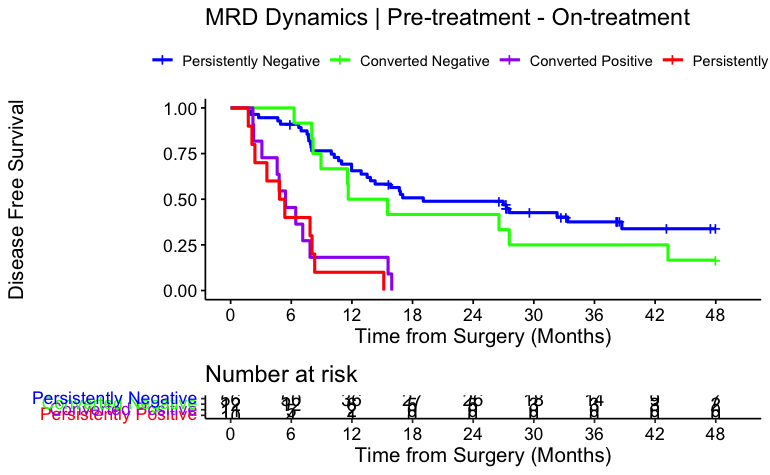

```r
surv_object <-Surv(time = circ_data$DFS_months, event = circ_data$RecStatus)
KM_curve <- survfit(surv_object ~ MRD_ChemoDynamics, data = circ_data,conf.int=0.95,conf.type="log-log")
ggsurvplot(KM_curve, data = circ_data, pval = FALSE, conf.int = FALSE, risk.table = TRUE, break.time.by=6, palette=c("blue","green","purple","red"), title="MRD Dynamics | Pre-treatment - On-treatment", ylab= "Disease Free Survival", xlab="Time from Surgery (Months)", legend.labs=c("Persistently Negative","Converted Negative","Converted Positive", "Persistently Positive"), legend.title="")
```

```r
summary(KM_curve, times= c(12, 24))
```

```
Call: survfit(formula = surv_object ~ MRD_ChemoDynamics, data = circ_data,
    conf.int = 0.95, conf.type = "log-log")

                MRD_ChemoDynamics=1
 time n.risk n.event survival std.err lower 95% CI upper 95% CI
   12     36      19    0.656  0.0640        0.515        0.765
   24     26       9    0.489  0.0677        0.351        0.613

                MRD_ChemoDynamics=2
 time n.risk n.event survival std.err lower 95% CI upper 95% CI
   12      6       6    0.500   0.144        0.208        0.736
   24      5       1    0.417   0.142        0.152        0.665

                MRD_ChemoDynamics=3
        time       n.risk      n.event     survival      std.err lower 95% CI upper 95% CI
     12.0000       2.0000       9.0000       0.1818       0.1163       0.0285       0.4417

                MRD_ChemoDynamics=4
        time       n.risk      n.event     survival      std.err lower 95% CI upper 95% CI
    12.00000      1.00000      9.00000      0.10000      0.09487      0.00572      0.35813
```

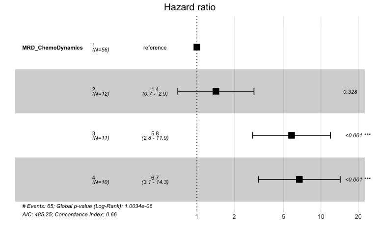

```r
circ_data$MRD_ChemoDynamics <- factor(circ_data$MRD_ChemoDynamics, levels=c("1","2","3","4"))
cox_fit <- coxph(surv_object ~ MRD_ChemoDynamics, data=circ_data)
ggforest(cox_fit,data = circ_data)
```

```r
summary(cox_fit)
```

```
Call:
coxph(formula = surv_object ~ MRD_ChemoDynamics, data = circ_data)

  n= 89, number of events= 65

                     coef exp(coef) se(coef)     z Pr(>|z|)
MRD_ChemoDynamics2 0.3528    1.4230   0.3607 0.978    0.328
MRD_ChemoDynamics3 1.7567    5.7935   0.3684 4.768 1.86e-06 ***
MRD_ChemoDynamics4 1.9013    6.6944   0.3869 4.914 8.94e-07 ***
---
Signif. codes:  0 ‘***’ 0.001 ‘**’ 0.01 ‘*’ 0.05 ‘.’ 0.1 ‘ ’ 1

                   exp(coef) exp(-coef) lower .95 upper .95
MRD_ChemoDynamics2     1.423     0.7027    0.7017     2.886
MRD_ChemoDynamics3     5.794     0.1726    2.8140    11.928
MRD_ChemoDynamics4     6.694     0.1494    3.1358    14.291

Concordance= 0.659  (se = 0.031 )
Likelihood ratio test= 30.66  on 3 df,   p=1e-06
Wald test            = 35.98  on 3 df,   p=8e-08
Score (logrank) test = 44.86  on 3 df,   p=1e-09
```

#Prognostic role of ctDNA C5D1 on Chemotherapy groups

```r
rm(list=ls())
setwd("~/Downloads")
circ_data <- read.csv("ASAN_ClinicalData_GL_082023.csv")
circ_data <- circ_data[circ_data$Chemo=="1",] #CAP group
circ_data$DFS_months=circ_data$DFS_months-2
circ_data <- circ_data[circ_data$DFS_months>=0,]
circ_data$DFS_months[circ_data$DFS_months > 60] <- 60
circ_datadf <- as.data.frame(circ_data)

survfit(Surv(time = circ_data$DFS_months, event = circ_data$RecStatus)~ctDNA.C5D1, data = circ_data)
```

```
Call: survfit(formula = Surv(time = circ_data$DFS_months, event = circ_data$RecStatus) ~
    ctDNA.C5D1, data = circ_data)

              n events median 0.95LCL 0.95UCL
ctDNA.C5D1=0 36     24  15.58   11.57      NA
ctDNA.C5D1=1  8      8   3.95    2.27      NA
```

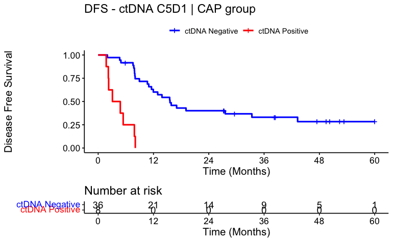

```r
surv_object <-Surv(time = circ_data$DFS_months, event = circ_data$RecStatus)
KM_curve <- survfit(surv_object ~ ctDNA.C5D1, data = circ_data,conf.int=0.95,conf.type="log-log")
ggsurvplot(KM_curve, data = circ_data, pval = FALSE, conf.int = FALSE, risk.table = TRUE, break.time.by=12, palette=c("blue","red"), title="DFS - ctDNA C5D1 | CAP group", ylab= "Disease Free Survival", xlab="Time (Months)", legend.labs=c("ctDNA Negative", "ctDNA Positive"), legend.title="")
```

```r
summary(KM_curve, times= c(0))
```

```
Call: survfit(formula = surv_object ~ ctDNA.C5D1, data = circ_data,
    conf.int = 0.95, conf.type = "log-log")

                ctDNA.C5D1=0
        time       n.risk      n.event     survival      std.err lower 95% CI upper 95% CI
           0           36            0            1            0            1            1

                ctDNA.C5D1=1
        time       n.risk      n.event     survival      std.err lower 95% CI upper 95% CI
           0            8            0            1            0            1            1
```

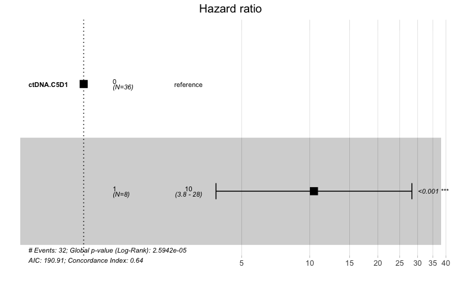

```r
circ_data$ctDNA.C5D1 <- factor(circ_data$ctDNA.C5D1, levels=c("0","1"))
cox_fit <- coxph(surv_object ~ ctDNA.C5D1, data=circ_data)
ggforest(cox_fit,data = circ_data)
```

```r
summary(cox_fit)
```

```
Call:
coxph(formula = surv_object ~ ctDNA.C5D1, data = circ_data)

  n= 44, number of events= 32

               coef exp(coef) se(coef)     z Pr(>|z|)
ctDNA.C5D11  2.3449   10.4322   0.5089 4.608 4.07e-06 ***
---
Signif. codes:  0 ‘***’ 0.001 ‘**’ 0.01 ‘*’ 0.05 ‘.’ 0.1 ‘ ’ 1

            exp(coef) exp(-coef) lower .95 upper .95
ctDNA.C5D11     10.43    0.09586     3.848     28.28

Concordance= 0.642  (se = 0.037 )
Likelihood ratio test= 17.69  on 1 df,   p=3e-05
Wald test            = 21.23  on 1 df,   p=4e-06
Score (logrank) test = 31.1  on 1 df,   p=2e-08
```

```r
cox_fit_summary <- summary(cox_fit)

# Extract values for HR, 95% CI, and p-value
HR <- cox_fit_summary$coefficients[2]
lower_CI <- cox_fit_summary$conf.int[3]
upper_CI <- cox_fit_summary$conf.int[4]
p_value <- cox_fit_summary$coefficients[5]
label_text <- paste0("HR = ", round(HR, 2), " (", round(lower_CI, 2), "-", round(upper_CI, 2), "); p = ", round(p_value, 3))
print(label_text)
```

```
[1] "HR = 10.43 (3.85-28.28); p = 0"
```

```r
rm(list=ls())
setwd("~/Downloads")
circ_data <- read.csv("ASAN_ClinicalData_GL_082023.csv")
circ_data <- circ_data[circ_data$Chemo=="2",] #GemCis group
circ_data$DFS_months=circ_data$DFS_months-2
circ_data <- circ_data[circ_data$DFS_months>=0,]
circ_data$DFS_months[circ_data$DFS_months > 60] <- 60
circ_datadf <- as.data.frame(circ_data)

survfit(Surv(time = circ_data$DFS_months, event = circ_data$RecStatus)~ctDNA.C5D1, data = circ_data)
```

```
Call: survfit(formula = Surv(time = circ_data$DFS_months, event = circ_data$RecStatus) ~
    ctDNA.C5D1, data = circ_data)

   1 observation deleted due to missingness
              n events median 0.95LCL 0.95UCL
ctDNA.C5D1=0 35     24  16.79   11.96    38.7
ctDNA.C5D1=1  9      9   4.83    3.59      NA
```

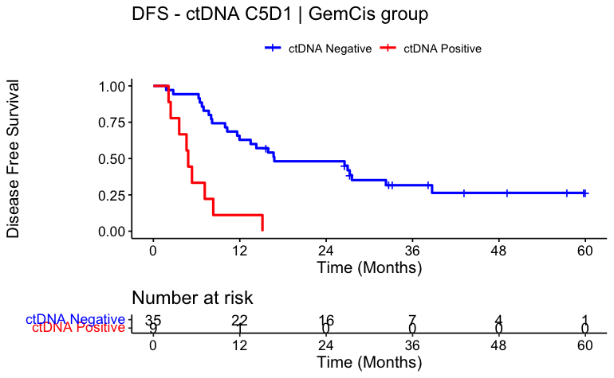

```r
surv_object <-Surv(time = circ_data$DFS_months, event = circ_data$RecStatus)
KM_curve <- survfit(surv_object ~ ctDNA.C5D1, data = circ_data,conf.int=0.95,conf.type="log-log")
ggsurvplot(KM_curve, data = circ_data, pval = FALSE, conf.int = FALSE, risk.table = TRUE, break.time.by=12, palette=c("blue","red"), title="DFS - ctDNA C5D1 | GemCis group", ylab= "Disease Free Survival", xlab="Time (Months)", legend.labs=c("ctDNA Negative", "ctDNA Positive"), legend.title="")
```

```r
summary(KM_curve, times= c(0))
```

```
Call: survfit(formula = surv_object ~ ctDNA.C5D1, data = circ_data,
    conf.int = 0.95, conf.type = "log-log")

1 observation deleted due to missingness
                ctDNA.C5D1=0
        time       n.risk      n.event     survival      std.err lower 95% CI upper 95% CI
           0           35            0            1            0            1            1

                ctDNA.C5D1=1
        time       n.risk      n.event     survival      std.err lower 95% CI upper 95% CI
           0            9            0            1            0            1            1
```

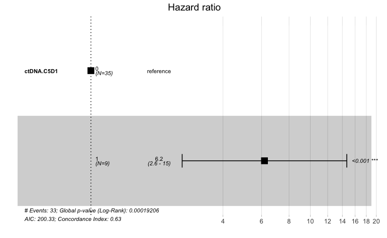

```r
circ_data$ctDNA.C5D1 <- factor(circ_data$ctDNA.C5D1, levels=c("0","1"))
cox_fit <- coxph(surv_object ~ ctDNA.C5D1, data=circ_data)
ggforest(cox_fit,data = circ_data)
```

```r
summary(cox_fit)
```

```
Call:
coxph(formula = surv_object ~ ctDNA.C5D1, data = circ_data)

  n= 44, number of events= 33
   (1 observation deleted due to missingness)

              coef exp(coef) se(coef)     z Pr(>|z|)
ctDNA.C5D11 1.8216    6.1816   0.4408 4.133 3.58e-05 ***
---
Signif. codes:  0 ‘***’ 0.001 ‘**’ 0.01 ‘*’ 0.05 ‘.’ 0.1 ‘ ’ 1

            exp(coef) exp(-coef) lower .95 upper .95
ctDNA.C5D11     6.182     0.1618     2.606     14.66

Concordance= 0.635  (se = 0.036 )
Likelihood ratio test= 13.91  on 1 df,   p=2e-04
Wald test            = 17.08  on 1 df,   p=4e-05
Score (logrank) test = 21.6  on 1 df,   p=3e-06
```

```r
cox_fit_summary <- summary(cox_fit)

# Extract values for HR, 95% CI, and p-value
HR <- cox_fit_summary$coefficients[2]
lower_CI <- cox_fit_summary$conf.int[3]
upper_CI <- cox_fit_summary$conf.int[4]
p_value <- cox_fit_summary$coefficients[5]
label_text <- paste0("HR = ", round(HR, 2), " (", round(lower_CI, 2), "-", round(upper_CI, 2), "); p = ", round(p_value, 3))
print(label_text)
```

```
[1] "HR = 6.18 (2.61-14.66); p = 0"
```

#Prognostic role of ctDNA C8D1 on Chemotherapy groups

```r
rm(list=ls())
setwd("~/Downloads")
circ_data <- read.csv("ASAN_ClinicalData_GL_082023.csv")
circ_data <- circ_data[circ_data$Chemo=="1",] #CAP group
circ_data$DFS_months=circ_data$DFS_months-2
circ_data <- circ_data[circ_data$DFS_months>=0,]
circ_data$DFS_months[circ_data$DFS_months > 60] <- 60
circ_datadf <- as.data.frame(circ_data)

survfit(Surv(time = circ_data$DFS_months, event = circ_data$RecStatus)~ctDNA.C8D1, data = circ_data)
```

```
Call: survfit(formula = Surv(time = circ_data$DFS_months, event = circ_data$RecStatus) ~
    ctDNA.C8D1, data = circ_data)

   7 observations deleted due to missingness
              n events median 0.95LCL 0.95UCL
ctDNA.C8D1=0 31     20  15.84   11.57      NA
ctDNA.C8D1=1  6      6   7.86    5.43      NA
```

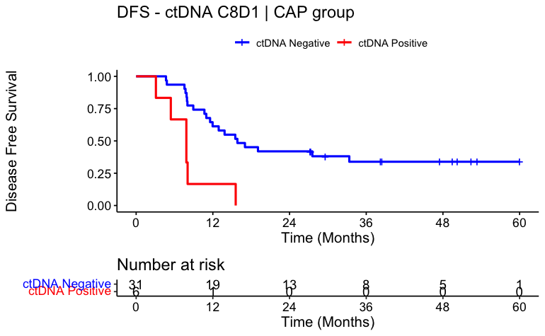

```r
surv_object <-Surv(time = circ_data$DFS_months, event = circ_data$RecStatus)
KM_curve <- survfit(surv_object ~ ctDNA.C8D1, data = circ_data,conf.int=0.95,conf.type="log-log")
ggsurvplot(KM_curve, data = circ_data, pval = FALSE, conf.int = FALSE, risk.table = TRUE, break.time.by=12, palette=c("blue","red"), title="DFS - ctDNA C8D1 | CAP group", ylab= "Disease Free Survival", xlab="Time (Months)", legend.labs=c("ctDNA Negative", "ctDNA Positive"), legend.title="")
```

```r
summary(KM_curve, times= c(0))
```

```
Call: survfit(formula = surv_object ~ ctDNA.C8D1, data = circ_data,
    conf.int = 0.95, conf.type = "log-log")

7 observations deleted due to missingness
                ctDNA.C8D1=0
        time       n.risk      n.event     survival      std.err lower 95% CI upper 95% CI
           0           31            0            1            0            1            1

                ctDNA.C8D1=1
        time       n.risk      n.event     survival      std.err lower 95% CI upper 95% CI
           0            6            0            1            0            1            1
```

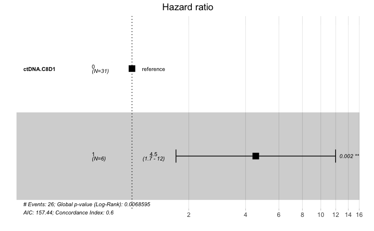

```r
circ_data$ctDNA.C8D1 <- factor(circ_data$ctDNA.C8D1, levels=c("0","1"))
cox_fit <- coxph(surv_object ~ ctDNA.C8D1, data=circ_data)
ggforest(cox_fit,data = circ_data)
```

```r
summary(cox_fit)
```

```
Call:
coxph(formula = surv_object ~ ctDNA.C8D1, data = circ_data)

  n= 37, number of events= 26
   (7 observations deleted due to missingness)

              coef exp(coef) se(coef)     z Pr(>|z|)
ctDNA.C8D11 1.5101    4.5272   0.4964 3.042  0.00235 **
---
Signif. codes:  0 ‘***’ 0.001 ‘**’ 0.01 ‘*’ 0.05 ‘.’ 0.1 ‘ ’ 1

            exp(coef) exp(-coef) lower .95 upper .95
ctDNA.C8D11     4.527     0.2209     1.711     11.98

Concordance= 0.601  (se = 0.039 )
Likelihood ratio test= 7.31  on 1 df,   p=0.007
Wald test            = 9.26  on 1 df,   p=0.002
Score (logrank) test = 11.02  on 1 df,   p=9e-04
```

```r
cox_fit_summary <- summary(cox_fit)

# Extract values for HR, 95% CI, and p-value
HR <- cox_fit_summary$coefficients[2]
lower_CI <- cox_fit_summary$conf.int[3]
upper_CI <- cox_fit_summary$conf.int[4]
p_value <- cox_fit_summary$coefficients[5]
label_text <- paste0("HR = ", round(HR, 2), " (", round(lower_CI, 2), "-", round(upper_CI, 2), "); p = ", round(p_value, 3))
print(label_text)
```

```
[1] "HR = 4.53 (1.71-11.98); p = 0.002"
```

```r
rm(list=ls())
setwd("~/Downloads")
circ_data <- read.csv("ASAN_ClinicalData_GL_082023.csv")
circ_data <- circ_data[circ_data$Chemo=="2",] #GemCis group
circ_data$DFS_months=circ_data$DFS_months-2
circ_data <- circ_data[circ_data$DFS_months>=0,]
circ_data$DFS_months[circ_data$DFS_months > 60] <- 60
circ_datadf <- as.data.frame(circ_data)

survfit(Surv(time = circ_data$DFS_months, event = circ_data$RecStatus)~ctDNA.C8D1, data = circ_data)
```

```
Call: survfit(formula = Surv(time = circ_data$DFS_months, event = circ_data$RecStatus) ~
    ctDNA.C8D1, data = circ_data)

   5 observations deleted due to missingness
              n events median 0.95LCL 0.95UCL
ctDNA.C8D1=0 31     20  26.98   13.51      NA
ctDNA.C8D1=1  9      9   6.44    4.83      NA
```

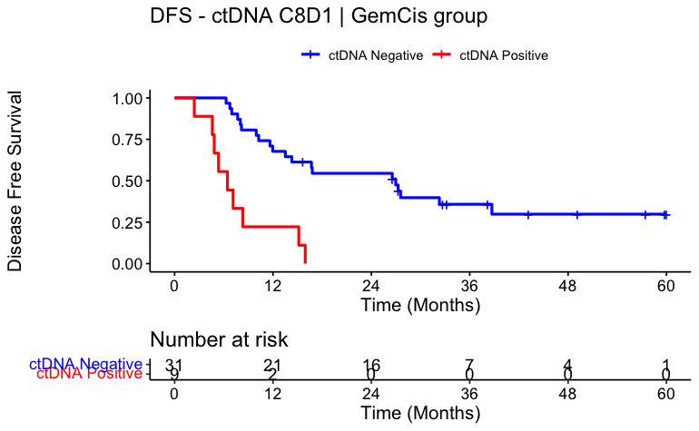

```r
surv_object <-Surv(time = circ_data$DFS_months, event = circ_data$RecStatus)
KM_curve <- survfit(surv_object ~ ctDNA.C8D1, data = circ_data,conf.int=0.95,conf.type="log-log")
ggsurvplot(KM_curve, data = circ_data, pval = FALSE, conf.int = FALSE, risk.table = TRUE, break.time.by=12, palette=c("blue","red"), title="DFS - ctDNA C8D1 | GemCis group", ylab= "Disease Free Survival", xlab="Time (Months)", legend.labs=c("ctDNA Negative", "ctDNA Positive"), legend.title="")
```

```r
summary(KM_curve, times= c(0))
```

```
Call: survfit(formula = surv_object ~ ctDNA.C8D1, data = circ_data,
    conf.int = 0.95, conf.type = "log-log")

5 observations deleted due to missingness
                ctDNA.C8D1=0
        time       n.risk      n.event     survival      std.err lower 95% CI upper 95% CI
           0           31            0            1            0            1            1

                ctDNA.C8D1=1
        time       n.risk      n.event     survival      std.err lower 95% CI upper 95% CI
           0            9            0            1            0            1            1
```

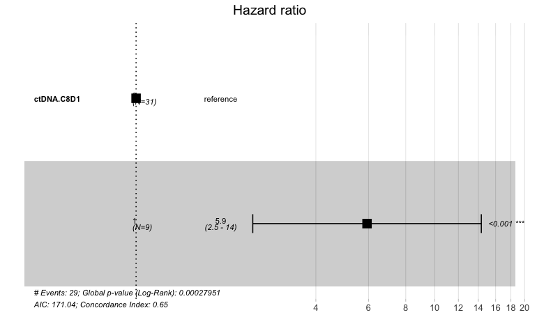

```r
circ_data$ctDNA.C8D1 <- factor(circ_data$ctDNA.C8D1, levels=c("0","1"))
cox_fit <- coxph(surv_object ~ ctDNA.C8D1, data=circ_data)
ggforest(cox_fit,data = circ_data)
```

```r
summary(cox_fit)
```

```
Call:
coxph(formula = surv_object ~ ctDNA.C8D1, data = circ_data)

  n= 40, number of events= 29
   (5 observations deleted due to missingness)

              coef exp(coef) se(coef)     z Pr(>|z|)
ctDNA.C8D11 1.7808    5.9345   0.4496 3.961 7.46e-05 ***
---
Signif. codes:  0 ‘***’ 0.001 ‘**’ 0.01 ‘*’ 0.05 ‘.’ 0.1 ‘ ’ 1

            exp(coef) exp(-coef) lower .95 upper .95
ctDNA.C8D11     5.935     0.1685     2.459     14.32

Concordance= 0.649  (se = 0.039 )
Likelihood ratio test= 13.2  on 1 df,   p=3e-04
Wald test            = 15.69  on 1 df,   p=7e-05
Score (logrank) test = 19.94  on 1 df,   p=8e-06
```

```r
cox_fit_summary <- summary(cox_fit)

# Extract values for HR, 95% CI, and p-value
HR <- cox_fit_summary$coefficients[2]
lower_CI <- cox_fit_summary$conf.int[3]
upper_CI <- cox_fit_summary$conf.int[4]
p_value <- cox_fit_summary$coefficients[5]
label_text <- paste0("HR = ", round(HR, 2), " (", round(lower_CI, 2), "-", round(upper_CI, 2), "); p = ", round(p_value, 3))
print(label_text)
```

```
[1] "HR = 5.93 (2.46-14.32); p = 0"
```

#Prognostic role of ctDNA C5D1 on Chemotherapy - 4 groups

```r
rm(list=ls())
setwd("~/Downloads")
circ_data <- read.csv("ASAN_ClinicalData_GL_082023.csv")
circ_data <- subset(circ_data, !is.na(ctDNA.C5D1))
circ_data$DFS_months=circ_data$DFS_months-2
circ_data <- circ_data[circ_data$DFS_months>=0,]
circ_data$DFS_months[circ_data$DFS_months > 60] <- 60


circ_data$ctDNA.C5D1.Chemo <- NA #first we create the variable for the ctDNA & NAC combination, and we assign values
circ_data <- circ_data %>%
  mutate(ctDNA.C5D1.Chemo = case_when(
    Chemo == 1 & ctDNA.C5D1 == 0 ~ 1,
    Chemo == 1 & ctDNA.C5D1 == 1 ~ 2,
    Chemo == 2 & ctDNA.C5D1 == 0 ~ 3,
    Chemo == 2 & ctDNA.C5D1 == 1 ~ 4
  ))
circ_datadf <- as.data.frame(circ_data)

survfit(Surv(time = circ_data$DFS_months, event = circ_data$RecStatus)~ctDNA.C5D1.Chemo, data = circ_data)
surv_object <-Surv(time = circ_data$DFS_months, event = circ_data$RecStatus)
KM_curve <- survfit(surv_object ~ ctDNA.C5D1.Chemo, data = circ_data,conf.int=0.95,conf.type="log-log")
ggsurvplot(KM_curve, data = circ_data, pval = FALSE, conf.int = FALSE, risk.table = TRUE, break.time.by=12, palette=c("blue","green","purple", "red"), title="DFS - ctDNA C5D1 & Chemotherapy Regimen", ylab= "Disease Free Survival", xlab="Months from surgery", legend.labs=c("CAP & ctDNA(-)", "CAP & ctDNA(+)","GemCis & ctDNA(-)", "GemCis & ctDNA(+)"), legend.title="")
summary(KM_curve, times= c(0))
circ_data$ctDNA.C5D1.Chemo <- factor(circ_data$ctDNA.C5D1.Chemo, levels=c("1","2","3","4"))
cox_fit <- coxph(surv_object ~ ctDNA.C5D1.Chemo, data=circ_data)
ggforest(cox_fit,data = circ_data)
summary(cox_fit)
cox_fit_summary <- summary(cox_fit)
```

[output not shown]

#Prognostic role of ctDNA C8D1 on Chemotherapy - 4 groups

```r
rm(list=ls())
setwd("~/Downloads")
circ_data <- read.csv("ASAN_ClinicalData_GL_082023.csv")
circ_data <- subset(circ_data, !is.na(ctDNA.C8D1))
circ_data$DFS_months=circ_data$DFS_months-2
circ_data <- circ_data[circ_data$DFS_months>=0,]
circ_data$DFS_months[circ_data$DFS_months > 60] <- 60


circ_data$ctDNA.C8D1.Chemo <- NA #first we create the variable for the ctDNA & NAC combination, and we assign values
circ_data <- circ_data %>%
  mutate(ctDNA.C8D1.Chemo = case_when(
    Chemo == 1 & ctDNA.C8D1 == 0 ~ 1,
    Chemo == 1 & ctDNA.C8D1 == 1 ~ 2,
    Chemo == 2 & ctDNA.C8D1 == 0 ~ 3,
    Chemo == 2 & ctDNA.C8D1 == 1 ~ 4
  ))
circ_datadf <- as.data.frame(circ_data)

survfit(Surv(time = circ_data$DFS_months, event = circ_data$RecStatus)~ctDNA.C8D1.Chemo, data = circ_data)
surv_object <-Surv(time = circ_data$DFS_months, event = circ_data$RecStatus)
KM_curve <- survfit(surv_object ~ ctDNA.C8D1.Chemo, data = circ_data,conf.int=0.95,conf.type="log-log")
ggsurvplot(KM_curve, data = circ_data, pval = FALSE, conf.int = FALSE, risk.table = TRUE, break.time.by=12, palette=c("blue","green","purple", "red"), title="DFS - ctDNA C8D1 & Chemotherapy Regimen", ylab= "Disease Free Survival", xlab="Time (Months)", legend.labs=c("CAP & ctDNA(-)", "CAP & ctDNA(+)","GemCis & ctDNA(-)", "GemCis & ctDNA(+)"), legend.title="")
summary(KM_curve, times= c(0))
circ_data$ctDNA.C8D1.Chemo <- factor(circ_data$ctDNA.C8D1.Chemo, levels=c("1","2","3","4"))
cox_fit <- coxph(surv_object ~ ctDNA.C8D1.Chemo, data=circ_data)
ggforest(cox_fit,data = circ_data)
summary(cox_fit)
cox_fit_summary <- summary(cox_fit)
```

[output not shown]

#Prognostic role of ctDNA C5D1 based on primary site

```r
rm(list=ls())
setwd("~/Downloads")
circ_data <- read.csv("ASAN_ClinicalData_GL_082023.csv")
circ_data <- circ_data[circ_data$PrimSite=="1",] #pCCA group
circ_data$DFS_months=circ_data$DFS_months-2
circ_data <- circ_data[circ_data$DFS_months>=0,]
circ_data$DFS_months[circ_data$DFS_months > 60] <- 60
circ_datadf <- as.data.frame(circ_data)

survfit(Surv(time = circ_data$DFS_months, event = circ_data$RecStatus)~ctDNA.C5D1, data = circ_data)
```

```
Call: survfit(formula = Surv(time = circ_data$DFS_months, event = circ_data$RecStatus) ~
    ctDNA.C5D1, data = circ_data)

              n events median 0.95LCL 0.95UCL
ctDNA.C5D1=0 34     28   15.7   11.63    27.3
ctDNA.C5D1=1  9      9    4.8    3.59      NA
```

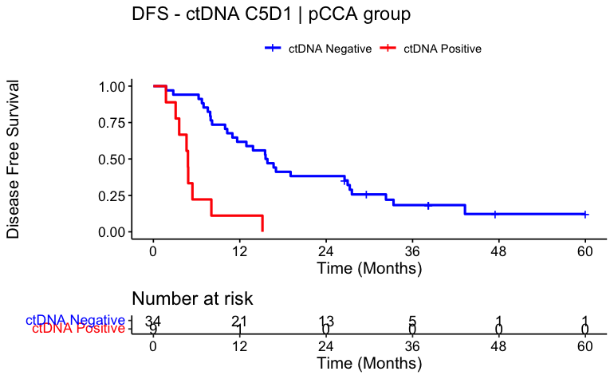

```r
surv_object <-Surv(time = circ_data$DFS_months, event = circ_data$RecStatus)
KM_curve <- survfit(surv_object ~ ctDNA.C5D1, data = circ_data,conf.int=0.95,conf.type="log-log")
ggsurvplot(KM_curve, data = circ_data, pval = FALSE, conf.int = FALSE, risk.table = TRUE, break.time.by=12, palette=c("blue","red"), title="DFS - ctDNA C5D1 | pCCA group", ylab= "Disease Free Survival", xlab="Time (Months)", legend.labs=c("ctDNA Negative", "ctDNA Positive"), legend.title="")
```

```r
summary(KM_curve, times= c(12, 24))
```

```
Call: survfit(formula = surv_object ~ ctDNA.C5D1, data = circ_data,
    conf.int = 0.95, conf.type = "log-log")

                ctDNA.C5D1=0
 time n.risk n.event survival std.err lower 95% CI upper 95% CI
   12     21      13    0.618  0.0833        0.434        0.757
   24     13       8    0.382  0.0833        0.223        0.540

                ctDNA.C5D1=1
        time       n.risk      n.event     survival      std.err lower 95% CI upper 95% CI
    12.00000      1.00000      8.00000      0.11111      0.10476      0.00613      0.38766
```

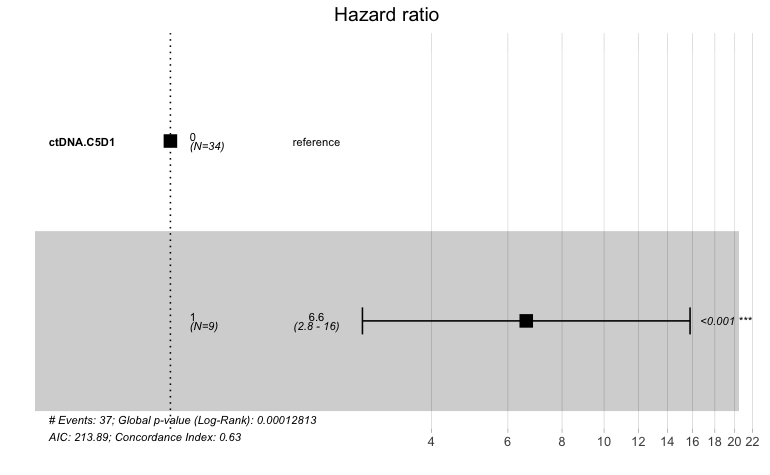

```r
circ_data$ctDNA.C5D1 <- factor(circ_data$ctDNA.C5D1, levels=c("0","1"))
cox_fit <- coxph(surv_object ~ ctDNA.C5D1, data=circ_data)
ggforest(cox_fit,data = circ_data)
```

```r
summary(cox_fit)
```

```
Call:
coxph(formula = surv_object ~ ctDNA.C5D1, data = circ_data)

  n= 43, number of events= 37

              coef exp(coef) se(coef)     z Pr(>|z|)
ctDNA.C5D11 1.8893    6.6150   0.4438 4.258 2.07e-05 ***
---
Signif. codes:  0 ‘***’ 0.001 ‘**’ 0.01 ‘*’ 0.05 ‘.’ 0.1 ‘ ’ 1

            exp(coef) exp(-coef) lower .95 upper .95
ctDNA.C5D11     6.615     0.1512     2.772     15.79

Concordance= 0.635  (se = 0.035 )
Likelihood ratio test= 14.67  on 1 df,   p=1e-04
Wald test            = 18.13  on 1 df,   p=2e-05
Score (logrank) test = 23.12  on 1 df,   p=2e-06
```

```r
cox_fit_summary <- summary(cox_fit)

# Extract values for HR, 95% CI, and p-value
HR <- cox_fit_summary$coefficients[2]
lower_CI <- cox_fit_summary$conf.int[3]
upper_CI <- cox_fit_summary$conf.int[4]
p_value <- cox_fit_summary$coefficients[5]
label_text <- paste0("HR = ", round(HR, 2), " (", round(lower_CI, 2), "-", round(upper_CI, 2), "); p = ", round(p_value, 3))
print(label_text)
```

```
[1] "HR = 6.62 (2.77-15.79); p = 0"
```